# 第7讲｜决策树与集成学习

我们先沿日期看每日共享单车租赁次数，再用一个气温指标学习分段预测。之后比较树的复杂度、样本扰动与集成方法。

**数据口径**：UCI Bike Sharing 的 `day.csv`，共 731 天。沿用第 6 讲约定：前 611 天为本轮开发数据，后 120 天仍不参与本轮拟合、选参与模型评价；仅在开头的全期数据概览中展示原始租赁量。`cnt` 表示每日租赁次数，不表示人数或车辆库存。`casual` 与 `registered` 相加就是 `cnt`，因此不能作为输入。

**本轮切分**：开发数据前 491 天用于拟合，后 120 天用于开发验证。后续时序交叉验证只在前 611 天内部进行。

```python
# 显示辅助：正文、表格与print输出统一放大，运行一次即可。
from IPython.display import display, HTML
notebook_style = """
.jp-RenderedHTMLCommon, .jp-RenderedMarkdown, .jp-OutputArea pre {
    font-size: 20px !important; line-height: 1.65 !important;
}
.dataframe, .dataframe th, .dataframe td {
    font-size: 20px !important; line-height: 1.6 !important;
}
"""
display(HTML(f"<style>{notebook_style}</style>"))
```

## 阅读路线与课件对应

本 Notebook 按课件顺序展开，代码旁保留实验说明。公式与推导可按需展开。

| 内容 | 对应课件 |
| --- | --- |
| 真实数据、回归树、切分准则与复杂度 | p2–12 |
| 分类树、Gini、熵、增益率与分类边界 | p13–24 |
| 单树与Bagging、训练扰动下的预测波动 | p25 |
| 随机森林原理与参数实验 | p26–29 |
| 梯度提升回归、分类与损失扩展 | p30–35 |
| AdaBoost、框架阅读、三种集成路线 | p36–40 |
| 作业：森林叶子下限对照 | p41 |

```python
from pathlib import Path
import json, sys, platform, time
import numpy as np
import pandas as pd
import matplotlib.pyplot as plt
from IPython.display import display, Image
from sklearn import __version__ as sklearn_version
from sklearn.tree import DecisionTreeRegressor, DecisionTreeClassifier, export_text
from sklearn.model_selection import TimeSeriesSplit
from sklearn.metrics import mean_squared_error, mean_absolute_error
from sklearn.ensemble import BaggingRegressor, RandomForestRegressor, GradientBoostingRegressor, GradientBoostingClassifier
```

```python
ROOT = Path.cwd().resolve()
while ROOT != ROOT.parent and not (ROOT / "lessons/06-model-selection").exists(): ROOT = ROOT.parent
RUN_STARTED = time.perf_counter()
LESSON = ROOT / "lessons/07-trees-ensembles"
ASSETS = LESSON / "assets"
HELPERS = LESSON / "notebook/helpers"
if str(HELPERS) not in sys.path: sys.path.insert(0, str(HELPERS))
import l7_bike_plots as plots
plt.rcParams.update({"figure.dpi": 110})
print(f"工作目录：{ROOT.name}；scikit-learn {sklearn_version}；随机种子 42")
```

```
工作目录：2026机器学习与概率统计-本科；scikit-learn 1.9.0；随机种子 42
```

## 1. 封面：先看时间里的租赁量

曲线展示2011—2012年全部731天，观察季节起伏与跨年变化。橙线为30日滑动均值（当日及之前29天的均值），仅辅助读图，不是模型预测。后续拟合与评价仍只使用前611天开发数据。

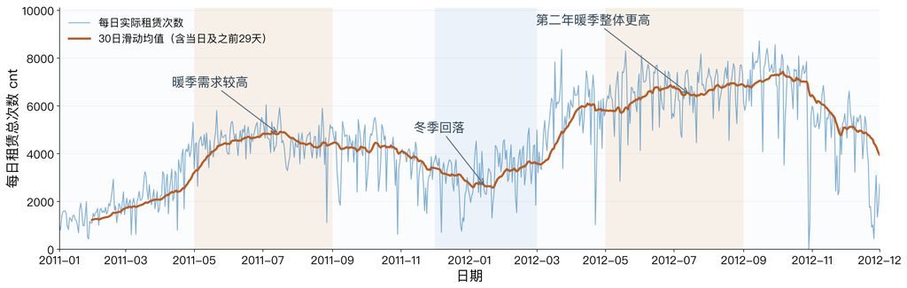

```
开发段：611 天；拟合：491 天；开发验证：120 天；旧预留：120 天（未用于本轮评价）
```

```python
bike_path = ROOT / "lessons/06-model-selection/notebook/data/bike-sharing/day.csv"
bike_all = pd.read_csv(bike_path, parse_dates=["dteday"])
development = bike_all.iloc[:611].copy()
fit_frame = development.iloc[:491].copy()
dev_valid = development.iloc[491:611].copy()
legacy_holdout = bike_all.iloc[611:].copy()
# 核对总行数与开发/旧预留切分口径。
assert len(bike_all) == 731 and len(fit_frame) == 491 and len(dev_valid) == 120 and len(legacy_holdout) == 120
plots.timeline(bike_all["dteday"], bike_all["cnt"], ASSETS / "l7-bike-timeline.svg")
display(Image(filename=str(ASSETS / "l7-bike-timeline.png")))
print("开发段：611 天；拟合：491 天；开发验证：120 天；旧预留：120 天（未用于本轮评价）")
```

## 2. 一种输入：气温指标与租赁次数

先只看样本分布，不画模型，也不预设阈值。`temp` 沿用UCI数据包提供的归一化气温。按随附 `Readme.txt`，其方法为最大值缩放（max scaling），即摄氏气温除以固定上界41；本Notebook直接使用，不重新拟合缩放器。

**短答**：低温区租赁量通常较少，高温端未持续上升；相近气温下仍有明显差异。橙线将样本按气温排序，对每41个相邻样本的气温与租赁次数分别取均值，用于观察平均趋势；两端不足完整窗口处不延伸。这不是按时间平均，也不是决策树预测。

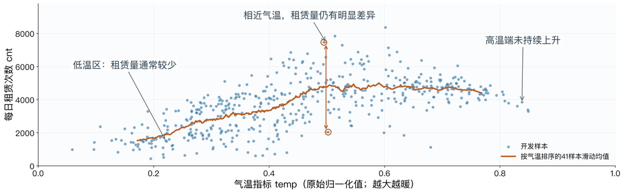

```python
x_fit = fit_frame["temp"].to_numpy()
y_fit = fit_frame["cnt"].to_numpy()
plots.scatter(x_fit, y_fit, ASSETS / "l7-bike-distribution.svg", observations=True)
display(Image(filename=str(ASSETS / "l7-bike-distribution.png")))
```

## 3. 一次切分：两片区域，各报一个均值

用前 491 天拟合一棵最多两片叶的回归树。竖线是真实学到的阈值，横线是各叶训练记录的均值。

**想一想**：同一片区域内，模型为什么给出相同预测？

**短答**：树只根据 `temp` 决定落在哪片区域，同一叶子的记录收到相同的常数预测。

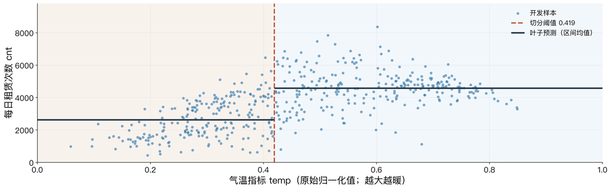

```
实际阈值：temp ≤ 0.419167；左区预测 2,628 次，右区预测 4,580 次。
```

```python
tree2 = DecisionTreeRegressor(max_leaf_nodes=2, random_state=42)
tree2.fit(x_fit.reshape(-1, 1), y_fit)
cut1 = float(tree2.tree_.threshold[0])
leaf2 = tree2.apply(x_fit.reshape(-1, 1))
means2 = [float(y_fit[leaf2 == leaf].mean()) for leaf in np.unique(leaf2)]
edges2 = [0.0, cut1, 1.0]
region_mids2 = np.array([(a+b)/2 for a,b in zip(edges2[:-1], edges2[1:])])
predictions2 = tree2.predict(region_mids2.reshape(-1,1)).tolist()
plots.scatter(x_fit, y_fit, ASSETS / "l7-bike-one-cut.svg", "一次切分：阈值与两片区域的叶均值", [cut1], predictions2)
display(Image(filename=str(ASSETS / "l7-bike-one-cut.png")))
print(f"实际阈值：temp ≤ {cut1:.6f}；左区预测 {predictions2[0]:,.0f} 次，右区预测 {predictions2[1]:,.0f} 次。")
```

## 4. 两次切分：三片区域

`max_leaf_nodes=3` 表示最多三个叶子，因而最多两次切分。它不是把 `max_depth=2` 当作同一配置。

**短答**：根切分相同，第二次切分继续细分根节点左侧的样本区域。

叶内预测为常数，因此曲线呈阶梯状；超出训练气温范围时，不会自动沿原趋势外推。

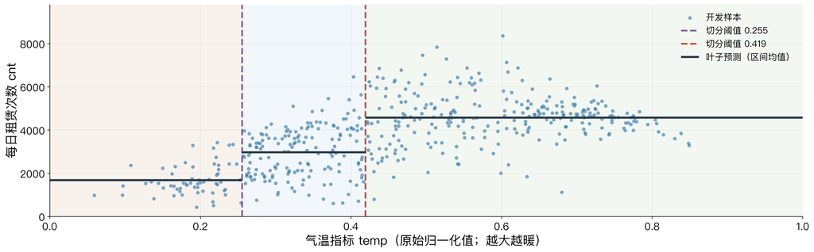

```
两种树根节点切分一致：0.419167；从左到右的叶预测为 [1689, 2974, 4580] 次。
```

```python
tree3 = DecisionTreeRegressor(max_leaf_nodes=3, random_state=42)
tree3.fit(x_fit.reshape(-1, 1), y_fit)
# 两种叶子上限必须从同一根阈值开始。
assert tree2.tree_.threshold[0] == tree3.tree_.threshold[0]
leaf3 = tree3.apply(x_fit.reshape(-1, 1))
cuts3 = sorted(float(v) for v in tree3.tree_.threshold if v >= 0)
edges3 = [0.0, *cuts3, 1.0]
region_mids3 = np.array([(a+b)/2 for a,b in zip(edges3[:-1], edges3[1:])])
predictions3 = tree3.predict(region_mids3.reshape(-1,1)).tolist()
plots.scatter(x_fit, y_fit, ASSETS / "l7-bike-two-cuts.svg", "两次切分：三片区域与各自叶均值", cuts3, predictions3)
display(Image(filename=str(ASSETS / "l7-bike-two-cuts.png")))
leaf_mean_by_node = {int(leaf): float(y_fit[leaf3 == leaf].mean()) for leaf in np.unique(leaf3)}
midpoint_nodes = tree3.apply(region_mids3.reshape(-1,1))
# 区间中点预测应与对应训练叶均值一致。
assert np.allclose(predictions3, [leaf_mean_by_node[int(node)] for node in midpoint_nodes])
print(f"两种树根节点切分一致：{cut1:.6f}；从左到右的叶预测为 {[round(v) for v in predictions3]} 次。")
```

## 5. 把同一模型画成树

每个判断条件把记录送往下一节点，叶子给出该区域训练租赁量的均值。星号标出一条拟合记录经过的叶子。 根节点（root node）是起点；根的深度为0，树深度按根到最深叶的边数计，本树为2。路径上的条件必须同时满足：中间叶对应气温指标大于约0.255且不超过约0.419，预测约2,974次（阈值为三位小数近似）。

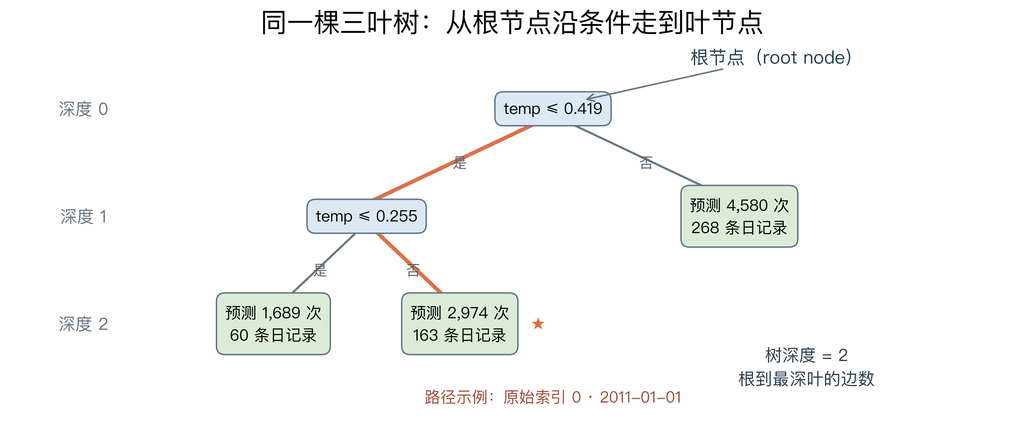

```
固定演示记录：索引 0，日期 2011-01-01，temp=0.344167；到叶节点 4，预测 2,974 次。此记录仅用于走路径。
```

```python
sample_row = 0
sample_leaf = int(tree3.apply(x_fit[sample_row:sample_row+1].reshape(-1, 1))[0])
sample_path = tree3.decision_path(x_fit[sample_row:sample_row+1].reshape(-1, 1)).indices.tolist()
sample_date = fit_frame.iloc[sample_row]["dteday"].strftime("%Y-%m-%d")
plots.tree_diagram(tree3, ["temp"], ASSETS / "l7-bike-tree.svg", sample_leaf, sample_path, f"路径示例：原始索引 {fit_frame.index[sample_row]} · {sample_date}")
display(Image(filename=str(ASSETS / "l7-bike-tree.png")))
print(f"固定演示记录：索引 {int(fit_frame.index[sample_row])}，日期 {sample_date}，temp={x_fit[sample_row]:.6f}；到叶节点 {sample_leaf}，预测 {tree3.predict(x_fit[sample_row:sample_row+1].reshape(-1, 1))[0]:,.0f} 次。此记录仅用于走路径。")
```

## 6. 叶子为什么报均值？

展示高亮路径所在叶子的真实记录。平方误差下，叶均值使该叶训练记录的平方误差和最小。

**短答**：固定同一片叶子的样本，让所有记录共用预测值 `c`，比较 `SSE(c) = sum((y - c)**2)`。最小值出现在叶内目标的均值处；固定样本数时，MSE只是SSE除以样本数，最优点相同。下图用该叶全部真实记录计算曲线，最低点约2,974次。若改用绝对误差，则最优常数为中位数。参见[sklearn：回归树准则](https://scikit-learn.org/stable/modules/tree.html#regression-criteria)。

|  | dteday | temp | cnt |
| --- | --- | --- | --- |
| 0 | 2011-01-01 | 0.344167 | 985 |
| 1 | 2011-01-02 | 0.363478 | 801 |
| 18 | 2011-01-19 | 0.292174 | 1650 |
| 19 | 2011-01-20 | 0.261667 | 1927 |
| 32 | 2011-02-02 | 0.260000 | 1526 |
| 36 | 2011-02-06 | 0.285833 | 1623 |
| 37 | 2011-02-07 | 0.271667 | 1712 |
| 43 | 2011-02-13 | 0.316522 | 1589 |

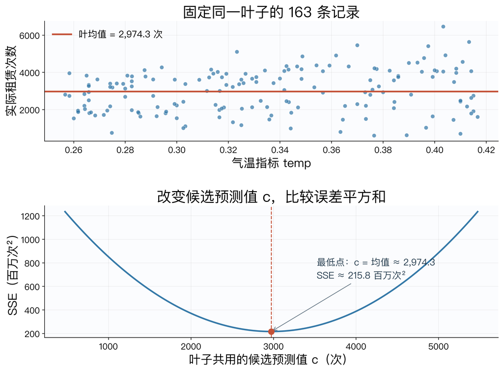

```
该叶共有 163 天，均值 2,974.3 次；表格仅预览 8 行。
```

```python
chosen_leaf = sample_leaf
chosen_mask = leaf3 == chosen_leaf
chosen_mean = float(y_fit[chosen_mask].mean())
leaf_records = fit_frame.loc[chosen_mask, ["dteday", "temp", "cnt"]].copy()
display(leaf_records.head(8).assign(dteday=lambda d: d.dteday.dt.strftime("%Y-%m-%d")))
plots.leaf_mean(x_fit, y_fit, chosen_mask, chosen_mean, ASSETS / "l7-bike-leaf-mean.svg")
display(Image(filename=str(ASSETS / "l7-bike-leaf-mean.png")))
print(f"该叶共有 {int(chosen_mask.sum())} 天，均值 {chosen_mean:,.1f} 次；表格仅预览 8 行。")
```

## 7. 怎样挑一次切分？

排序后只考虑相邻不同气温之间的中点。用前缀和维护两侧的样本数、目标和及目标平方和，快速计算所有候选的总SSE；不为每个候选重训整棵树。单个特征在当前节点的排序为O(n log n)，随后扫描为O(n)。

**短答**：SSE 越小，候选切分后各侧记录围绕各自均值的总平方偏差越小。

固定叶子内的$n$条记录，$\bar y$为目标均值：

$$\mathrm{SSE}=\sum_i(y_i-\bar y)^2=\sum_i y_i^2-\frac{(\sum_i y_i)^2}{n}.$$

因此扫描时只需维护每侧的样本数、目标和、目标平方和。叶子均值最优的推导见课件p7，等价式展开见课件p8的折叠说明。

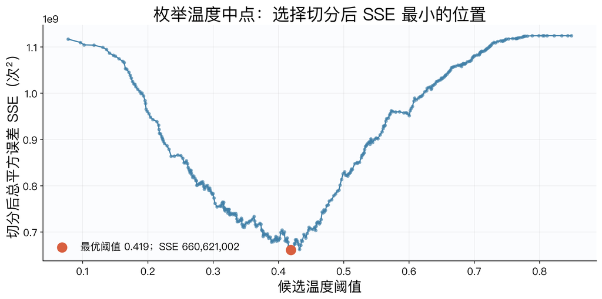

```
枚举最优阈值 0.419167；树根阈值 0.419167；两者差 1.20e-08。
```

```python
order = np.argsort(x_fit)
xs, ys = x_fit[order], y_fit[order]
candidate_idx = np.flatnonzero(xs[:-1] < xs[1:])
candidate_cuts = (xs[candidate_idx] + xs[candidate_idx + 1]) / 2
# 前缀和记录左组的目标和S、平方和Q；右组由总量减去左组得到。
counts_left = candidate_idx + 1
sums, squares = np.cumsum(ys, dtype=float), np.cumsum(ys.astype(float)**2)
s_left, q_left = sums[candidate_idx], squares[candidate_idx]
counts_right = len(ys) - counts_left
s_right, q_right = sums[-1] - s_left, squares[-1] - q_left
# 固定一组时，SSE = Q - S²/n；一次扫描就能比较所有候选。
sse_values = q_left - s_left**2/counts_left + q_right - s_right**2/counts_right
best_i = int(np.argmin(sse_values))
best_threshold = float(candidate_cuts[best_i])
plots.split_sse(candidate_cuts, sse_values, best_i, ASSETS / "l7-bike-split.svg")
display(Image(filename=str(ASSETS / "l7-bike-split.png")))
print(f"枚举最优阈值 {best_threshold:.6f}；树根阈值 {cut1:.6f}；两者差 {abs(best_threshold-cut1):.2e}。")
```

```python
def node_rows(model, names):
    t=model.tree_; out=[]
    for i in range(t.node_count):
        f=int(t.feature[i]); out.append({"node_id":i,"feature":None if f<0 else names[f],"threshold":None if f<0 else float(t.threshold[i]),"left_child":int(t.children_left[i]),"right_child":int(t.children_right[i]),"sample_count":int(t.n_node_samples[i]),"value":float(t.value[i].reshape(-1)[0]),"impurity":float(t.impurity[i])})
    return out
core_results={"generated_on":"2026-10-30","data":{"source":"lessons/06-model-selection/notebook/data/bike-sharing/day.csv","rows_total":len(bike_all),"development_indices":development.index.tolist(),"fit_indices":fit_frame.index.tolist(),"dev_validation_indices":dev_valid.index.tolist(),"legacy_holdout_indices":legacy_holdout.index.tolist(),"development_dates":development.dteday.dt.strftime("%Y-%m-%d").tolist(),"fit_dates":fit_frame.dteday.dt.strftime("%Y-%m-%d").tolist(),"dev_validation_dates":dev_valid.dteday.dt.strftime("%Y-%m-%d").tolist(),"legacy_holdout_dates":legacy_holdout.dteday.dt.strftime("%Y-%m-%d").tolist()},"models":{"max_leaf_nodes_2":{"params":{"max_leaf_nodes":2,"random_state":42},"nodes":node_rows(tree2,["temp"])},"max_leaf_nodes_3":{"params":{"max_leaf_nodes":3,"random_state":42},"nodes":node_rows(tree3,["temp"]),"root_threshold_matches_two_leaf_tree":bool(tree2.tree_.threshold[0]==tree3.tree_.threshold[0])}},"selected_leaf":{"sample_index":int(fit_frame.index[sample_row]),"sample_date":sample_date,"sample_temp":float(x_fit[sample_row]),"leaf_node":chosen_leaf,"record_indices":fit_frame.index[chosen_mask].tolist(),"mean_cnt":chosen_mean,"purpose":"fixed mechanism walk-through only"},"root_split_enumeration":{"candidate_midpoints":candidate_cuts.tolist(),"sse":sse_values.tolist(),"best_threshold":best_threshold,"best_sse":float(sse_values[best_i]),"tree_root_threshold":cut1},"figures":{"ref:l7-bike-timeline":"l7-bike-timeline.svg","ref:l7-bike-distribution":"l7-bike-distribution.svg","ref:l7-bike-one-cut":"l7-bike-one-cut.svg","ref:l7-bike-two-cuts":"l7-bike-two-cuts.svg","ref:l7-bike-tree":"l7-bike-tree.svg","ref:l7-bike-leaf-mean":"l7-bike-leaf-mean.svg","ref:l7-bike-split":"l7-bike-split.svg"},"environment":{"python":platform.python_version(),"numpy":np.__version__,"pandas":pd.__version__,"matplotlib":plt.matplotlib.__version__,"scikit_learn":sklearn_version}}
(ASSETS/"l7-bike-results.json").write_text(json.dumps(core_results,ensure_ascii=False,indent=2),encoding="utf-8")
print("核心图表、节点、切分候选及完整日期索引已写入 l7-bike-results.json。")
```

```
核心图表、节点、切分候选及完整日期索引已写入 l7-bike-results.json。
```

## 8. 回归准则对照：同一数据、三种划分

仍用前491天、同一气温特征，固定最多3片叶子和随机种子42，仅改变`criterion`。并排图采用相同坐标；虚线是实际切分，深色水平线是叶子预测，数字为预测租赁次数。

先看切分位置，再看叶子输出：三种准则第一次切分均约0.419；第二次切分中，平方误差约0.255，绝对误差与泊松偏差约0.236。后两者分组相同，但中位数与均值仍可给出不同预测。这是训练机制对照，不是泛化性能排名。

```python
criteria_models = {}
# 固定数据、特征和复杂度，仅更换回归准则。
for criterion in ["squared_error", "absolute_error", "poisson"]:
    model = DecisionTreeRegressor(criterion=criterion, max_leaf_nodes=3, random_state=42)
    model.fit(x_fit[:, None], y_fit)
    criteria_models[criterion] = model
```

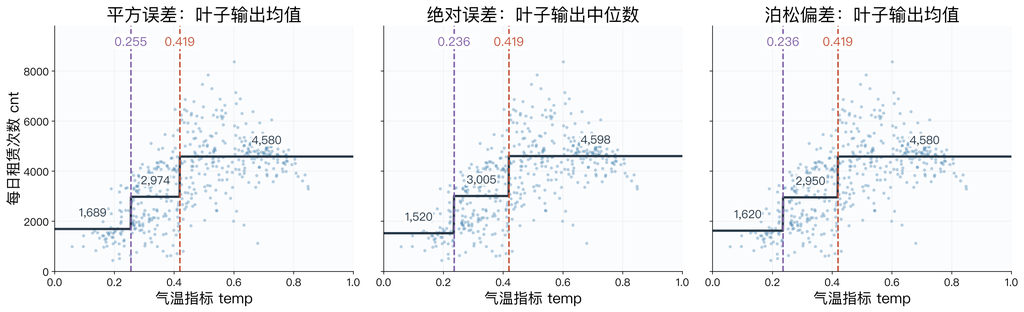

|  | criterion | 阈值（从小到大） | 叶预测（从左到右） |
| --- | --- | --- | --- |
| 0 | squared_error | [0.25541698932647705, 0.41916701197624207] | [1688.65, 2974.325153374233, 4580.067164179104] |
| 1 | absolute_error | [0.23583300411701202, 0.41916701197624207] | [1519.5, 3005.0, 4598.5] |
| 2 | poisson | [0.23583300411701202, 0.41916701197624207] | [1620.4074074074074, 2950.4852071005917, 4580.... |

```python
plots.criteria_comparison(x_fit, y_fit, criteria_models, ASSETS / "l7-bike-criteria-compare.svg")
display(Image(filename=str(ASSETS / "l7-bike-criteria-compare.png")))
criteria_rows = []
for criterion, model in criteria_models.items():
    cuts = np.sort(model.tree_.threshold[model.tree_.feature >= 0])
    mids = (np.r_[0, cuts] + np.r_[cuts, 1]) / 2
    criteria_rows.append({"criterion": criterion, "阈值（从小到大）": cuts.tolist(), "叶预测（从左到右）": model.predict(mids[:, None]).tolist()})
display(pd.DataFrame(criteria_rows))
_ = (ASSETS / "l7-bike-criteria-compare.json").write_text(json.dumps(criteria_rows, ensure_ascii=False, indent=2))
```

## 9. 教学合成数据：有波动的散点与两次切分

这是教学合成数据，不是UCI记录。100个特征值在0到1之间随机分布；需求均值连续变化，再生成带随机波动的非负计数，并在两个低特征值附近额外加入高值。随机种子固定42。

三种模型都最多3片叶子（两次切分），仅改变criterion。阈值按从小到大排列：平方误差约0.135、0.298；绝对误差约0.135、0.371；泊松偏差约0.178、0.319。相同散点可能得到不同分组，均值与中位数也会影响叶子输出。该构造不用于给算法排名。

```python
rng_synthetic = np.random.default_rng(42)
synthetic_x = np.sort(rng_synthetic.uniform(0, 1, 100))
# 平均需求连续变化；负二项抽样只用于生成有波动的非负计数。
synthetic_mean = 8 + 100*synthetic_x + 35*np.sin(np.pi*synthetic_x)
synthetic_y = rng_synthetic.negative_binomial(12, 12/(12+synthetic_mean)).astype(float)
for position in [.18, .32]:
    synthetic_y[np.argmin(abs(synthetic_x-position))] += 180
synthetic_models = {}
for criterion in ["squared_error", "absolute_error", "poisson"]:
    model = DecisionTreeRegressor(criterion=criterion, max_leaf_nodes=3, random_state=42)
    model.fit(synthetic_x[:, None], synthetic_y)
    synthetic_models[criterion] = model
```

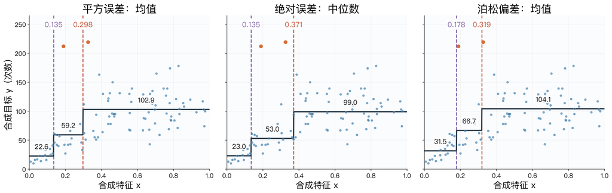

|  | criterion | 阈值（从小到大） | 叶预测（从左到右） |
| --- | --- | --- | --- |
| 0 | squared_error | [0.13483699411153793, 0.2975529283285141] | [22.615384615384617, 59.1875, 102.88732394366197] |
| 1 | absolute_error | [0.13483699411153793, 0.37062886357307434] | [23.0, 53.0, 99.0] |
| 2 | poisson | [0.1782221421599388, 0.31909599900245667] | [31.526315789473685, 66.6923076923077, 104.117... |

```python
plots.synthetic_criteria(synthetic_x, synthetic_y, synthetic_models, ASSETS / "l7-bike-criteria-synthetic.svg")
display(Image(filename=str(ASSETS / "l7-bike-criteria-synthetic.png")))
synthetic_rows = []
for criterion, model in synthetic_models.items():
    cuts = np.sort(model.tree_.threshold[model.tree_.feature >= 0])
    mids = (np.r_[0, cuts] + np.r_[cuts, 1]) / 2
    synthetic_rows.append({"criterion": criterion, "阈值（从小到大）": cuts.tolist(), "叶预测（从左到右）": model.predict(mids[:, None]).tolist()})
display(pd.DataFrame(synthetic_rows))
_ = (ASSETS / "l7-bike-criteria-synthetic.json").write_text(json.dumps({"source":"teaching synthetic", "seed":42, "x":synthetic_x.tolist(), "y":synthetic_y.tolist(), "max_leaf_nodes":3, "models":synthetic_rows}, ensure_ascii=False, indent=2))
```

## 10. 树变深：训练误差与时序验证误差

固定开发段内的三折时序交叉验证（TimeSeriesSplit）。每折只用过去记录训练、用紧随其后的区间验证；候选深度为 1、2、3、5、8 与不限制。随后固定max_depth=None，比较min_samples_leaf=1、3、5、10、20、40。两边使用同一批时序验证折，图上保留每折验证点。

```python
depths = [1, 2, 3, 5, 8, None]
tscv = TimeSeriesSplit(n_splits=3)
complexity_rows, complexity_train = [], []
for depth in depths:
    fold_mse, fold_train = [], []
    for tr, va in tscv.split(development):
        model = DecisionTreeRegressor(max_depth=depth, random_state=42)
        model.fit(development.iloc[tr][["temp"]], development.iloc[tr]["cnt"])
        fold_train.append(mean_squared_error(development.iloc[tr]["cnt"], model.predict(development.iloc[tr][["temp"]])))
        fold_mse.append(mean_squared_error(development.iloc[va]["cnt"], model.predict(development.iloc[va][["temp"]])))
    complexity_rows.append(fold_mse); complexity_train.append(float(np.mean(fold_train)))
display(pd.DataFrame({"深度": [*depths[:-1], "不限制"], "训练 MSE": complexity_train, "验证 MSE 均值": np.mean(complexity_rows,axis=1)}).round(0))
```

|  | 深度 | 训练 MSE | 验证 MSE 均值 |
| --- | --- | --- | --- |
| 0 | 1 | 732618.0 | 3251533.0 |
| 1 | 2 | 599790.0 | 2983246.0 |
| 2 | 3 | 551171.0 | 2983449.0 |
| 3 | 5 | 468503.0 | 3021707.0 |
| 4 | 8 | 298119.0 | 3214311.0 |
| 5 | 不限制 | 93621.0 | 3424303.0 |

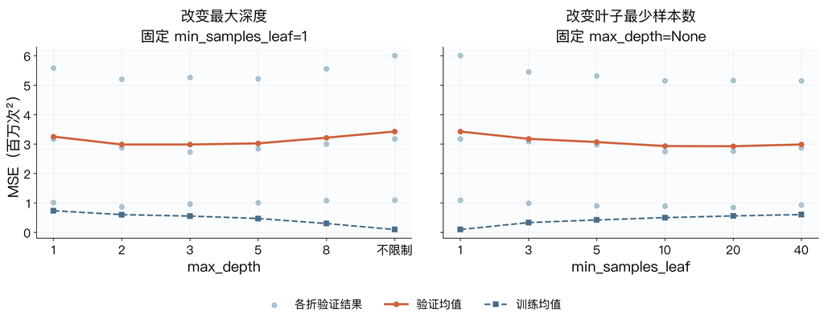

|  | min_samples_leaf | 训练MSE | 验证MSE均值 |
| --- | --- | --- | --- |
| 0 | 1 | 93621.0 | 3424303.0 |
| 1 | 3 | 329280.0 | 3176461.0 |
| 2 | 5 | 419236.0 | 3066396.0 |
| 3 | 10 | 498635.0 | 2929395.0 |
| 4 | 20 | 556127.0 | 2923980.0 |
| 5 | 40 | 602069.0 | 2983356.0 |

```python
leaf_sizes = [1, 3, 5, 10, 20, 40]
leaf_rows, leaf_train = [], []
for size in leaf_sizes:
    fold_mse, fold_train = [], []
    for tr, va in tscv.split(development):
        model = DecisionTreeRegressor(min_samples_leaf=size, max_depth=None, random_state=42)
        model.fit(development.iloc[tr][["temp"]], development.iloc[tr]["cnt"])
        fold_train.append(mean_squared_error(development.iloc[tr]["cnt"], model.predict(development.iloc[tr][["temp"]])))
        fold_mse.append(mean_squared_error(development.iloc[va]["cnt"], model.predict(development.iloc[va][["temp"]])))
    leaf_rows.append(fold_mse); leaf_train.append(float(np.mean(fold_train)))
plots.complexity([1,2,3,5,8,10], complexity_train, complexity_rows, ASSETS / "l7-bike-complexity.svg", leaf_sizes, leaf_train, leaf_rows)
display(Image(filename=str(ASSETS / "l7-bike-complexity.png")))
display(pd.DataFrame({"min_samples_leaf": leaf_sizes, "训练MSE": leaf_train, "验证MSE均值": np.mean(leaf_rows,axis=1)}).round(0))
_ = (ASSETS / "l7-bike-leaf-size.json").write_text(json.dumps({"leaf_sizes":leaf_sizes,"train_mean":leaf_train,"valid_per_fold":leaf_rows,"fixed_max_depth":None,"splitter":"TimeSeriesSplit(n_splits=3)"},indent=2))
```

### 复杂度控制也可以在整棵树长出后进行

`max_depth`、`min_samples_leaf`在生长时限制切分。**代价复杂度剪枝（Cost-Complexity Pruning）**则比较预测误差与叶子数量，删除收益不足的子树。`ccp_alpha`越大，通常偏好叶子更少的树。这里的复杂度指树的规模，不是运行时间。

本节实验仍只改变深度或叶子样本下限，剪枝不额外展开训练。课件p11 · [sklearn剪枝说明](https://scikit-learn.org/stable/modules/tree.html#minimal-cost-complexity-pruning)

## 11. 重抽样让单树发生变化

固定同一批 491 天，按行有放回抽样 30 次，每次重新拟合树。曲线表示训练样本扰动带来的预测变化；这是独立同分布行重抽的示意，不是时间序列不确定性推断。

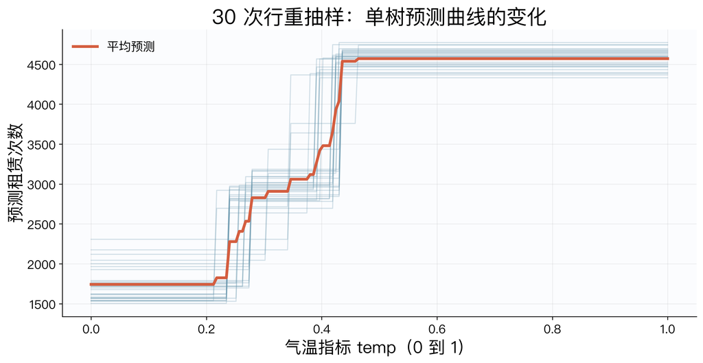

```
30 条曲线来自 30 次行重抽拟合；解释范围限于样本扰动示意。
```

```python
rng = np.random.default_rng(42)
xgrid = np.linspace(0, 1, 180).reshape(-1, 1)
bootstrap_curves = []
for _ in range(30):
    idx = rng.integers(0, len(x_fit), len(x_fit))
    model = DecisionTreeRegressor(max_leaf_nodes=3, random_state=42)
    model.fit(x_fit[idx, None], y_fit[idx])
    bootstrap_curves.append(model.predict(xgrid))
bootstrap_curves = np.asarray(bootstrap_curves)
plots.curves(xgrid[:,0], bootstrap_curves, bootstrap_curves.mean(axis=0), ASSETS / "l7-bike-instability.svg", "30 次行重抽样：单树预测曲线的变化")
display(Image(filename=str(ASSETS / "l7-bike-instability.png")))
print("30 条曲线来自 30 次行重抽拟合；解释范围限于样本扰动示意。")
```

## 12. 从租赁次数派生需求类别

定义高需求日为 `cnt >= 4000`，这是本课的教学标签，不是 UCI 原生标签。输入只用 `temp` 与 `hum`；`cnt` 只用于生成标签，绝不作为输入。样本仍是前 491 天。

```python
demand_threshold = 4000
demand_y = (y_fit >= demand_threshold).astype(int)
demand_features = ["temp", "hum"]
X_demand = fit_frame[demand_features]
```

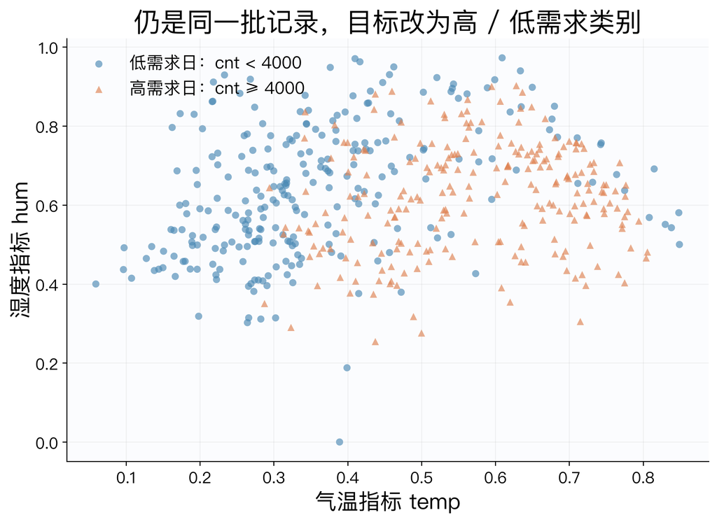

```python
import classification_story as class_plots
class_plots.demand_scatter(X_demand, demand_y, ASSETS / "l7-classification-inputs.svg")
display(Image(filename=str(ASSETS / "l7-classification-inputs.png")))
```

### 为什么不直接按错分率选切分？

构造10条记录：8个高需求、2个低需求。这不是UCI实际输出。假设某个输入条件将其分为“5高0低”与“3高2低”。先比较多数类预测的错分条数与节点内类别比例。

```python
toy_labels = np.array([1] * 8 + [0] * 2)
toy_left, toy_right = toy_labels[:5], toy_labels[5:]
toy_groups = [("父节点", toy_labels), ("左组", toy_left), ("右组", toy_right)]
toy_rows = []
for name, labels in toy_groups:
    p_high = labels.mean()
    predicted_class = int(p_high >= 0.5)
    toy_rows.append({"节点": name, "天数": len(labels), "高需求比例": p_high,
                     "错分条数": int(np.sum(labels != predicted_class))})
display(pd.DataFrame(toy_rows))
```

|  | 节点 | 天数 | 高需求比例 | 错分条数 |
| --- | --- | --- | --- | --- |
| 0 | 父节点 | 10 | 0.8 | 2 |
| 1 | 左组 | 5 | 1.0 | 0 |
| 2 | 右组 | 5 | 0.6 | 2 |

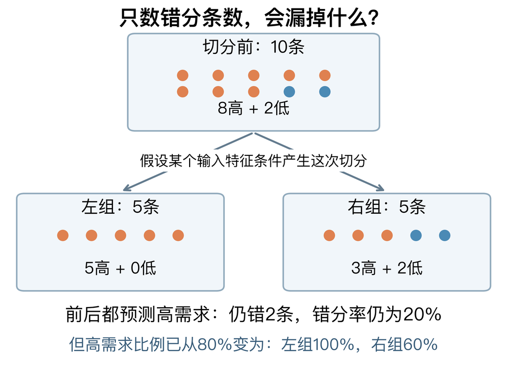

```
前后都错2条，训练错分率仍是20%；节点内高需求比例已有区别。
```

```python
class_plots.error_split(ASSETS / "l7-classification-error-motivation.svg")
display(Image(filename=str(ASSETS / "l7-classification-error-motivation.png")))
print("前后都错2条，训练错分率仍是20%；节点内高需求比例已有区别。")
```

### 从两次抽样构造混杂评分

在**同一个节点内**，按该节点类别比例独立、有放回地抽取两条记录，看标签是否不同。父节点8高2低，异类有两种顺序：

$$0.8\times0.2+0.2\times0.8=0.32.$$

左组5高0低，异类概率为0；右组3高2低，为$0.6\times0.4+0.4\times0.6=0.48$。两组各5条，按人数加权为$0.5\times0+0.5\times0.48=0.24$。

这个加权含义是先按组大小选一个节点，再在选中的节点内独立抽两条；不是在左右节点各抽一条。这里只计算评分，无需真的随机抽样或重训。

```python
pair_rows = []
for name, labels in toy_groups:
    p_high = labels.mean()
    high_then_low = p_high * (1 - p_high)
    low_then_high = (1 - p_high) * p_high
    pair_rows.append({"节点": name, "先高后低": high_then_low,
                      "先低后高": low_then_high, "异类概率": high_then_low + low_then_high})
display(pd.DataFrame(pair_rows).round(2))
weighted_difference = (len(toy_left) * pair_rows[1]["异类概率"]
                       + len(toy_right) * pair_rows[2]["异类概率"]) / len(toy_labels)
print(f"按人数加权后的混杂评分：{weighted_difference:.2f}，切分前为0.32。")
```

|  | 节点 | 先高后低 | 先低后高 | 异类概率 |
| --- | --- | --- | --- | --- |
| 0 | 父节点 | 0.16 | 0.16 | 0.32 |
| 1 | 左组 | 0.00 | 0.00 | 0.00 |
| 2 | 右组 | 0.24 | 0.24 | 0.48 |

```
按人数加权后的混杂评分：0.24，切分前为0.32。
```

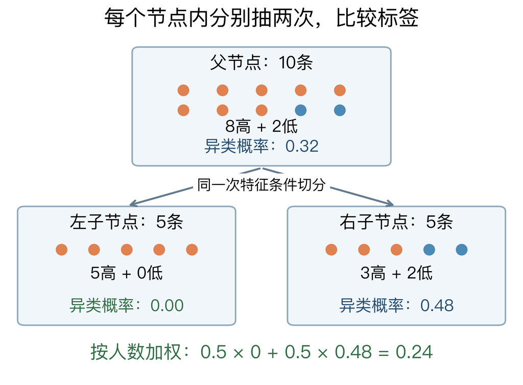

```python
class_plots.sampling_nodes(ASSETS / "l7-classification-sampling-nodes.svg")
display(Image(filename=str(ASSETS / "l7-classification-sampling-nodes.png")))
```

### 命名为Gini，并推广到一般公式

上一段的异类概率就是**基尼不纯度（Gini Impurity）**。若有$K$类，第$k$类比例为$p_k$，独立抽取的两次标签$Y_1,Y_2$同为$k$类的概率是$p_k^2$。对所有类别求和，再取补集：

$$P(Y_1=Y_2)=\sum_k p_k^2,\qquad G=P(Y_1\ne Y_2)=1-\sum_k p_k^2.$$

二分类写成$G=2p(1-p)$。它不是多数类预测器的错分率。对于0/1标签，以叶内正类比例$p=\bar y$预测概率：

$$\frac1n\sum_i(y_i-p)^2=p(1-p),\qquad G=2\times\mathrm{MSE}.$$

这里的符号为：

- $n$：叶子中的训练样本数。
- $y_i$：真实标签，高需求为1，低需求为0。
- $p$：叶内高需求比例，也是该叶子对所有样本给出的高需求预测概率。

因此，比较加权Gini与比较训练概率平方误差等价；这里不是将概率阈值化后的错误率。

参考：[Berkeley：Gini的概率解释](https://stat154.berkeley.edu/fall-2026/lectures/unit4/unit4_cart.html#node-impurity) · [sklearn分类准则](https://scikit-learn.org/stable/modules/tree.html#classification-criteria)。

```python
def class_gini(labels):
    proportions = np.bincount(labels, minlength=2) / len(labels)
    return 1 - np.sum(proportions ** 2)
```

```python
# 数值核对：同一个评分，也可以由通式直接得到。
toy_after_gini = (len(toy_left) * class_gini(toy_left)
                  + len(toy_right) * class_gini(toy_right)) / len(toy_labels)
print(f"Gini：{class_gini(toy_labels):.2f} → {toy_after_gini:.2f}")
print(f"二分类概率MSE：{class_gini(toy_labels)/2:.2f} → {toy_after_gini/2:.2f}")
# 抽样定义与Gini通式应给出相同结果。
assert np.isclose(weighted_difference, toy_after_gini)
```

```
Gini：0.32 → 0.24
二分类概率MSE：0.16 → 0.12
```

|  | 高需求比例p | 叶内概率MSE | Gini（2倍MSE） |
| --- | --- | --- | --- |
| 0 | 0.0 | 0.00 | 0.00 |
| 1 | 0.5 | 0.25 | 0.50 |
| 2 | 0.8 | 0.16 | 0.32 |
| 3 | 1.0 | 0.00 | 0.00 |

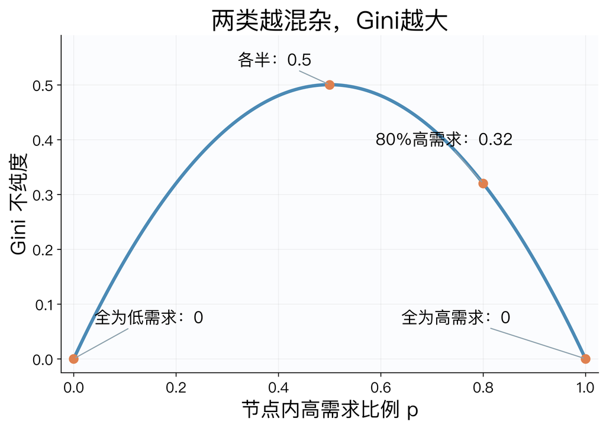

```python
node_probabilities = np.array([0.0, 0.5, 0.8, 1.0])
node_mse = node_probabilities * (1 - node_probabilities)
display(pd.DataFrame({"高需求比例p": node_probabilities, "叶内概率MSE": node_mse,
                      "Gini（2倍MSE）": 2 * node_mse}))
class_plots.gini_curve(ASSETS / "l7-classification-gini-curve.svg")
display(Image(filename=str(ASSETS / "l7-classification-gini-curve.png")))
```

### 回到真实记录：训练并检查分类树

以下仍用前491天的`temp`、`hum`，高需求标签由`cnt>=4000`产生。固定`criterion="gini"`、深度3、叶子最少20条、随机种子42。模型搜索合法候选，选择按子节点人数加权后Gini下降最多的分支，再递归。

纯节点、无合法切分或复杂度限制都可能使递归停止；叶子不必只有一个类别。

```python
demand_tree = DecisionTreeClassifier(criterion="gini",max_depth=3,min_samples_leaf=20,random_state=42)
demand_tree.fit(X_demand,demand_y)
print(f"高需求标签定义：cnt ≥ {demand_threshold}；高需求天数 {demand_y.sum()}/491。")
```

```
高需求标签定义：cnt ≥ 4000；高需求天数 234/491。
```

```python
demand_routes = demand_tree.decision_path(X_demand).toarray().astype(bool)
demand_nodes = []
for node in range(demand_tree.tree_.node_count):
    counts = [int(np.sum(demand_routes[:,node] & (demand_y==k))) for k in (0,1)]
    f = int(demand_tree.tree_.feature[node])
    probs=(np.asarray(counts,dtype=float)/sum(counts)).tolist()
    demand_nodes.append({"node_id":node,"feature":None if f<0 else demand_features[f],"threshold":None if f<0 else float(demand_tree.tree_.threshold[node]),"left_child":int(demand_tree.tree_.children_left[node]),"right_child":int(demand_tree.tree_.children_right[node]),"sample_count":sum(counts),"class_counts":counts,"class_probabilities":probs,"gini":float(1-sum(p*p for p in probs))})
demand_leaves = demand_tree.apply(X_demand)
demand_leaf_rows = []
for leaf in np.unique(demand_leaves):
    mask = demand_leaves==leaf
    counts = [int(np.sum(mask & (demand_y==k))) for k in (0,1)]
    demand_leaf_rows.append({"leaf":int(leaf),"counts_low_high":counts,"probabilities_low_high":(np.array(counts)/sum(counts)).tolist()})
display(pd.DataFrame(demand_nodes)); display(pd.DataFrame(demand_leaf_rows))
```

|  | node_id | feature | threshold | left_child | right_child | sample_count | class_counts | class_probabilities | gini |
| --- | --- | --- | --- | --- | --- | --- | --- | --- | --- |
| 0 | 0 | temp | 0.389546 | 1 | 8 | 491 | [257, 234] | [0.5234215885947047, 0.47657841140529533] | 0.498903 |
| 1 | 1 | temp | 0.340834 | 2 | 5 | 193 | [172, 21] | [0.8911917098445595, 0.10880829015544041] | 0.193938 |
| 2 | 2 | temp | 0.286666 | 3 | 4 | 150 | [144, 6] | [0.96, 0.04] | 0.076800 |
| 3 | 3 | NaN | NaN | -1 | -1 | 98 | [98, 0] | [1.0, 0.0] | 0.000000 |
| 4 | 4 | NaN | NaN | -1 | -1 | 52 | [46, 6] | [0.8846153846153846, 0.11538461538461539] | 0.204142 |
| 5 | 5 | hum | 0.668541 | 6 | 7 | 43 | [28, 15] | [0.6511627906976745, 0.3488372093023256] | 0.454300 |
| 6 | 6 | NaN | NaN | -1 | -1 | 20 | [9, 11] | [0.45, 0.55] | 0.495000 |
| 7 | 7 | NaN | NaN | -1 | -1 | 23 | [19, 4] | [0.8260869565217391, 0.17391304347826086] | 0.287335 |
| 8 | 8 | hum | 0.848541 | 9 | 12 | 298 | [85, 213] | [0.28523489932885904, 0.714765100671141] | 0.407752 |
| 9 | 9 | temp | 0.463750 | 10 | 11 | 267 | [62, 205] | [0.23220973782771537, 0.7677902621722846] | 0.356577 |
| 10 | 10 | NaN | NaN | -1 | -1 | 61 | [28, 33] | [0.45901639344262296, 0.5409836065573771] | 0.496641 |
| 11 | 11 | NaN | NaN | -1 | -1 | 206 | [34, 172] | [0.1650485436893204, 0.8349514563106796] | 0.275615 |
| 12 | 12 | NaN | NaN | -1 | -1 | 31 | [23, 8] | [0.7419354838709677, 0.25806451612903225] | 0.382934 |

|  | leaf | counts_low_high | probabilities_low_high |
| --- | --- | --- | --- |
| 0 | 3 | [98, 0] | [1.0, 0.0] |
| 1 | 4 | [46, 6] | [0.8846153846153846, 0.11538461538461539] |
| 2 | 6 | [9, 11] | [0.45, 0.55] |
| 3 | 7 | [19, 4] | [0.8260869565217391, 0.17391304347826086] |
| 4 | 10 | [28, 33] | [0.45901639344262296, 0.5409836065573771] |
| 5 | 11 | [34, 172] | [0.1650485436893204, 0.8349514563106796] |
| 6 | 12 | [23, 8] | [0.7419354838709677, 0.25806451612903225] |

```python
def gini_from_counts(counts):
    p=np.asarray(counts,dtype=float)/sum(counts); return float(1-np.sum(p*p))
root_feature=demand_features[int(demand_tree.tree_.feature[0])]
root_threshold=float(demand_tree.tree_.threshold[0])
left_mask=X_demand[root_feature].to_numpy()<=root_threshold
parent_counts=np.bincount(demand_y,minlength=2).astype(int).tolist()
left_counts=np.bincount(demand_y[left_mask],minlength=2).astype(int).tolist()
right_counts=np.bincount(demand_y[~left_mask],minlength=2).astype(int).tolist()
parent_gini=gini_from_counts(parent_counts); left_gini=gini_from_counts(left_counts); right_gini=gini_from_counts(right_counts)
weighted_child_gini=(sum(left_counts)*left_gini+sum(right_counts)*right_gini)/len(demand_y)
root_split={"parent_counts":parent_counts,"left_counts":left_counts,"right_counts":right_counts,"parent_gini":parent_gini,"left_gini":left_gini,"right_gini":right_gini,"weighted_child_gini":weighted_child_gini,"gain":parent_gini-weighted_child_gini}
print("根节点 Gini：",root_split)
```

```
根节点 Gini： {'parent_counts': [257, 234], 'left_counts': [172, 21], 'right_counts': [85, 213], 'parent_gini': 0.4989028583754008, 'left_gini': 0.1939380922977798, 'right_gini': 0.4077519030674295, 'weighted_child_gini': 0.32370696319259773, 'gain': 0.1751958951828031}
```

实际根分裂与一个湿度条件对照，各画成一棵深度1的树。两者使用同一批491条记录；B是人工候选，不代表最佳湿度阈值。节点内标明低/高需求天数与Gini，底部按子节点人数加权。

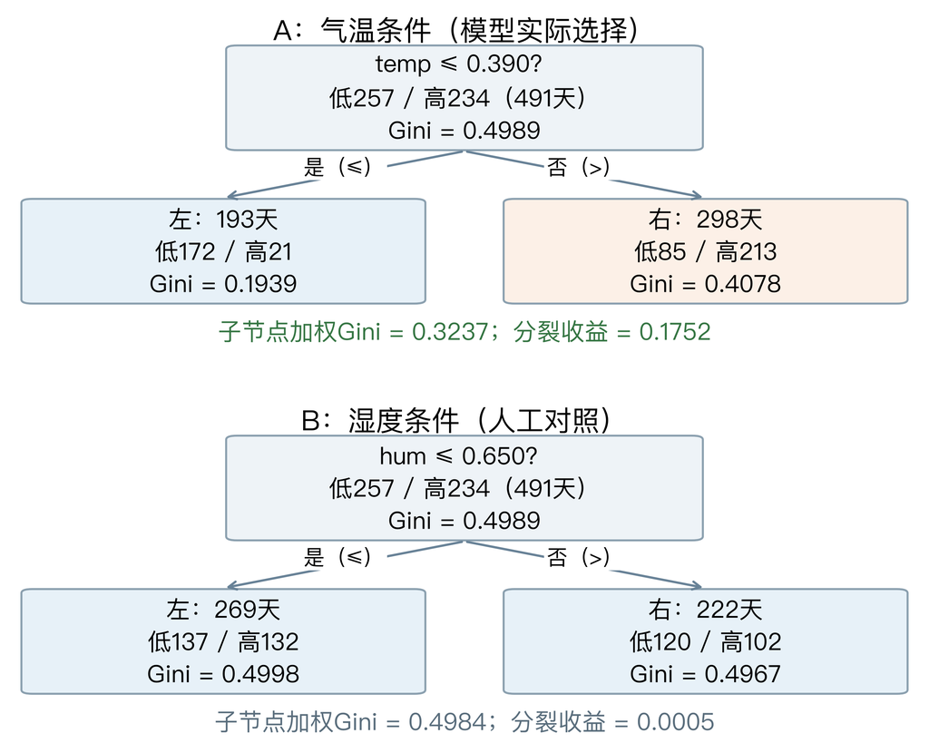

```python
split_count_cases = []
for split_feature, split_threshold in [(root_feature, root_threshold), ("hum", 0.65)]:
    option_left = X_demand[split_feature].to_numpy() <= split_threshold
    option_counts = [np.bincount(demand_y[mask], minlength=2).tolist()
                     for mask in [option_left, ~option_left]]
    split_count_cases.append({"feature": split_feature, "threshold": split_threshold,
                              "class_counts_low_high": option_counts})
class_plots.class_split_trees(split_count_cases, parent_counts, ASSETS / "l7-bike-class-split-trees.svg")
display(Image(filename=str(ASSETS / "l7-bike-class-split-trees.png")))
```

#### 不只比较两种方案：扫描全部合法候选

前面B的湿度0.65是人工条件，不是该特征最好的阈值。现在对`temp`和`hum`生成全部相邻不同值的中点，并按`min_samples_leaf=20`过滤。

对每个候选，只计算左右类别比例及加权Gini；无需重新训练一棵完整树。父节点Gini固定，所以最大化收益等价于最小化子节点加权Gini。

```python
split_thresholds = {}
for feature in demand_features:
    distinct_values = np.sort(X_demand[feature].unique())
    split_thresholds[feature] = (distinct_values[:-1] + distinct_values[1:]) / 2
print("过滤前的候选数：", {f: len(ts) for f, ts in split_thresholds.items()})
```

```
过滤前的候选数： {'temp': 382, 'hum': 434}
```

```python
gini_candidate_rows = []
for feature, thresholds in split_thresholds.items():
    values = X_demand[feature].to_numpy()
    for threshold in thresholds:
        left = values <= threshold
        n_left, n_right = int(left.sum()), int((~left).sum())
        if min(n_left, n_right) < demand_tree.min_samples_leaf:
            continue  # 叶子样本数不足时，不是合法切分。
        left_gini = class_gini(demand_y[left])
        right_gini = class_gini(demand_y[~left])
        weighted_gini = (n_left * left_gini + n_right * right_gini) / len(demand_y)
        gini_candidate_rows.append({"feature": feature, "threshold": threshold,
                                    "n_left": n_left, "n_right": n_right,
                                    "weighted_gini": weighted_gini, "gain": parent_gini - weighted_gini})
gini_candidate_table = pd.DataFrame(gini_candidate_rows)
```

|  | feature | threshold | gain |
| --- | --- | --- | --- |
| 726 | hum | 0.848541 | 0.012716 |
| 136 | temp | 0.389545 | 0.175196 |

```
合法候选数： {'hum': 396, 'temp': 348}
共744个候选；根节点选择temp≤0.3895455。
```

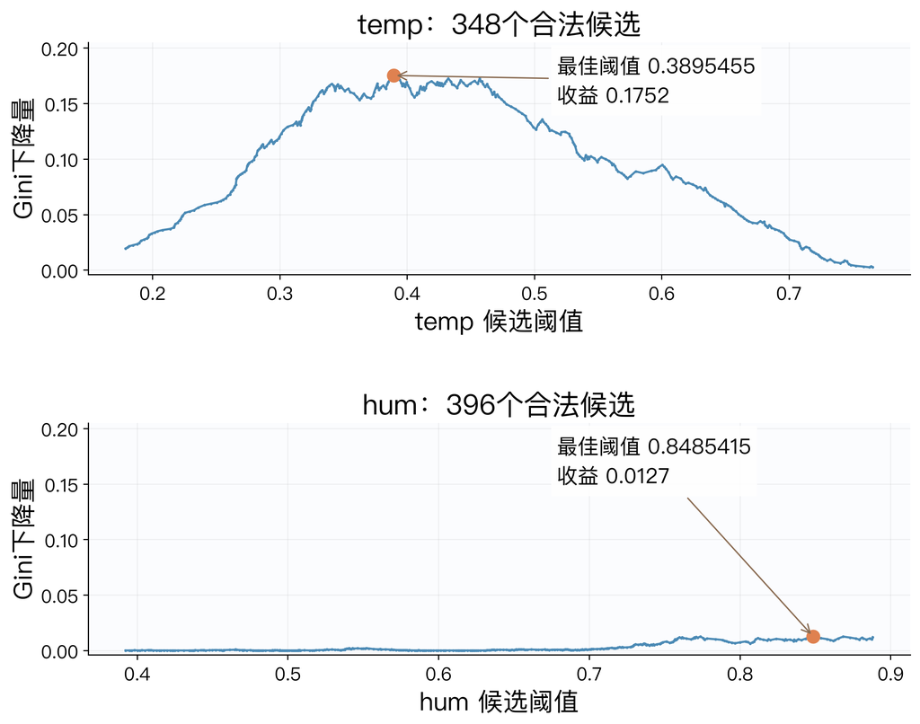

```python
best_per_feature = gini_candidate_table.loc[gini_candidate_table.groupby("feature")["gain"].idxmax()]
display(best_per_feature[["feature", "threshold", "gain"]].round(7))
print("合法候选数：", gini_candidate_table.groupby("feature").size().to_dict())
selected_split = gini_candidate_table.loc[gini_candidate_table["gain"].idxmax()]
print(f"共{len(gini_candidate_table)}个候选；根节点选择{selected_split['feature']}≤{selected_split['threshold']:.7f}。")
# 逐候选复算应还原实际模型的根分裂，容许浮点舍入差异。
assert selected_split["feature"] == root_feature and np.isclose(selected_split["threshold"], root_threshold, atol=1e-7, rtol=0)
class_plots.gini_search(gini_candidate_table, demand_features, ASSETS / "l7-classification-gini-search.svg")
display(Image(filename=str(ASSETS / "l7-classification-gini-search.png")))
```

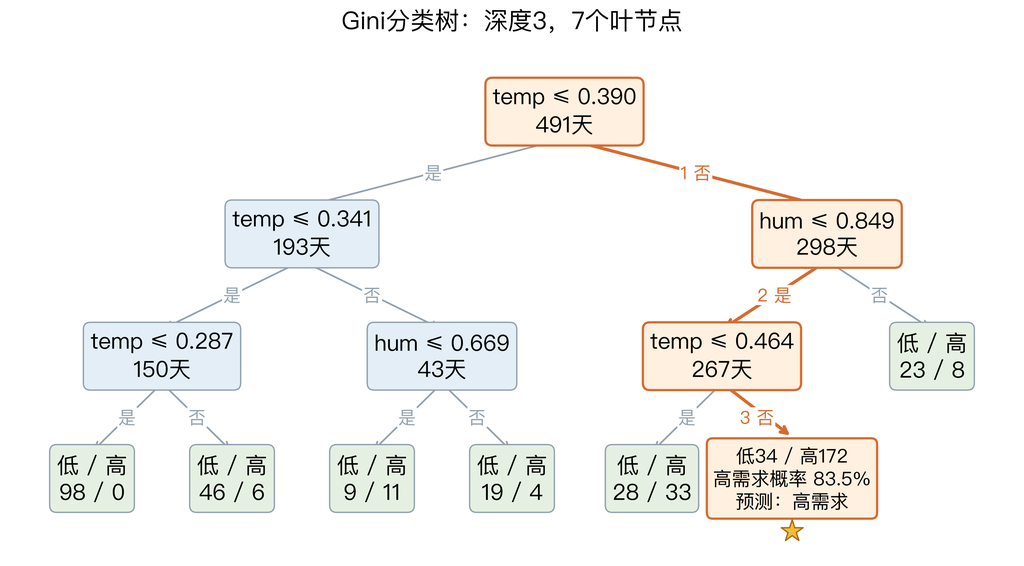

```python
class_example = pd.DataFrame({"temp": [0.50], "hum": [0.70]})
class_plots.demand_tree_depth3(demand_tree, X_demand, demand_y, demand_features,
                             ASSETS / "l7-bike-demand-class-depth3.svg", example=class_example)
display(Image(filename=str(ASSETS / "l7-bike-demand-class-depth3.png")))
```

### 沿路径计算叶子概率

示例输入`temp=0.50, hum=0.70`：气温大于约0.390，走右；湿度不超过约0.849，走左；气温大于约0.464，再走右。深度3的树将其分到含34个低需求日、172个高需求日的叶子，高需求概率为$172/206\approx83.5\%$，默认预测高需求。

橙色标出实际路径；叶内计数按“低/高”排列。示例输入用于演示，不冒充实际某个日期；训练叶内频率也不保证新数据自动校准。

```python
class_example_leaf = int(demand_tree.apply(class_example)[0])
class_example_path = demand_tree.decision_path(class_example).indices.tolist()
class_example_counts = np.bincount(demand_y[demand_leaves == class_example_leaf], minlength=2)
class_probabilities = demand_tree.predict_proba(class_example)[0]
print("实际路径节点：", class_example_path)
print("叶子编号：", class_example_leaf, "；低、高需求天数：", class_example_counts)
print("类别顺序：", demand_tree.classes_)
print("低、高需求概率：", np.round(class_probabilities, 4))
print("预测类别：", demand_tree.predict(class_example)[0])
```

```
实际路径节点： [0, 8, 9, 11]
叶子编号： 11 ；低、高需求天数： [ 34 172]
类别顺序： [0 1]
低、高需求概率： [0.165 0.835]
预测类别： 1
```

### 熵：类别还有多少不确定性？

Gini对应“两次独立抽样类别不同的概率”。熵从信息量出发：概率为$p$的结果，信息量定义为$I(p)=-\log_{2} p$；越罕见的结果，发生时信息量越大。按各类出现概率取平均，得到熵：

$$H=-\sum_k p_k\log_{2} p_k.$$

这里$p_k$为节点内第$k$类比例；约定$0\log_{2} 0=0$。使用以2为底的对数，单位为bit。二分类全同类时熵为0，各半时最大，为1 bit。若改用自然对数，最大值为ln2≈0.693，切分排序不变。

下图的10条记录是构造例子，不是UCI实际输出。右下曲线展示类别比例怎样影响熵。

参考：[Mitchell《Machine Learning》第3章](https://www.cs.cmu.edu/~tom/files/MachineLearningTomMitchell.pdf) · [UW CSE446：Information Gain](https://courses.cs.washington.edu/courses/cse446/20wi/Lecture3/03_InformationGain.pdf)。

|  | 高需求条数 | 低需求条数 | 熵（bit） |
| --- | --- | --- | --- |
| 0 | 10 | 0 | 0.000000 |
| 1 | 9 | 1 | 0.468996 |
| 2 | 5 | 5 | 1.000000 |

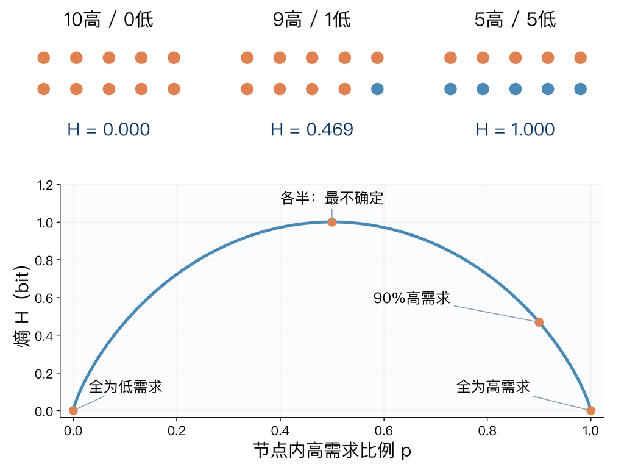

```
与sklearn根节点熵一致： 0.721928 bit
```

```python
def node_entropy(labels):
    proportions = np.bincount(labels, minlength=2) / len(labels)
    # 忽略零概率项，按约定令0 log₂ 0的贡献为0。
    positive = proportions[proportions > 0]
    return max(0.0, float(-np.sum(positive * np.log2(positive))))

entropy_examples = []
for high_count in [10, 9, 5]:
    labels = np.array([1] * high_count + [0] * (10 - high_count))
    entropy_examples.append({"高需求条数": high_count, "低需求条数": 10 - high_count,
                             "熵（bit）": node_entropy(labels)})
display(pd.DataFrame(entropy_examples).round(6))
class_plots.entropy_intro(ASSETS / "l7-entropy-intro.svg")
display(Image(filename=str(ASSETS / "l7-entropy-intro.png")))
# 同一标签分布的根节点熵应与sklearn一致。
entropy_check_tree = DecisionTreeClassifier(criterion="entropy", max_depth=1, random_state=42)
entropy_check_tree.fit(np.arange(len(toy_labels)).reshape(-1, 1), toy_labels)
assert np.isclose(entropy_check_tree.tree_.impurity[0], node_entropy(toy_labels))
print("与sklearn根节点熵一致：", round(entropy_check_tree.tree_.impurity[0], 6), "bit")
```

### 信息增益：比较切分前后的不确定性

沿用之前的8高2低，分成左侧5高0低、右侧3高2低。信息增益等于父节点熵减去子节点的加权熵：

$$\mathrm{IG}=H(\mathrm{parent})-\left[\frac{n_L}{n}H(L)+\frac{n_R}{n}H(R)\right].$$

$n$是父节点样本数，$n_L$和$n_R$为左右节点样本数。对合法候选分别计算，选择信息增益最大的切分。右子节点可以比父节点更混杂，比较的是加权后的整体评分。

```
父节点熵：0.721928；左节点：0.000000；右节点：0.970951
加权子熵：0.485475；信息增益：0.236453
```

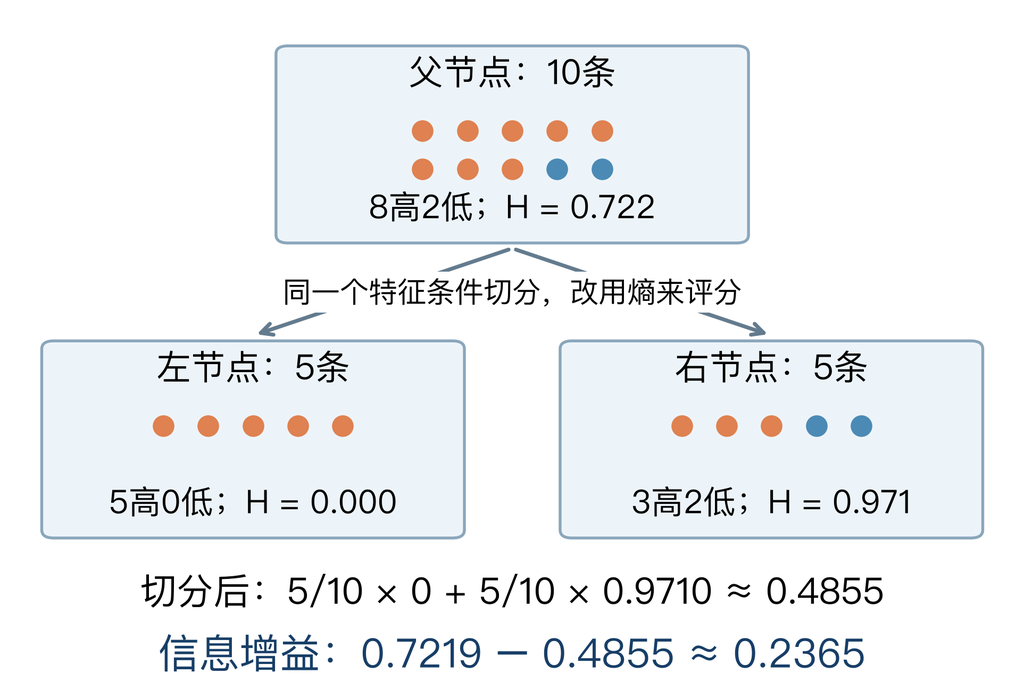

```python
parent_entropy = node_entropy(toy_labels)
left_entropy = node_entropy(toy_left)
right_entropy = node_entropy(toy_right)
# 按各组样本数加权，人数不同时不能直接取两组熵的简单平均。
after_entropy = (len(toy_left) * left_entropy + len(toy_right) * right_entropy) / len(toy_labels)
information_gain = parent_entropy - after_entropy
print(f"父节点熵：{parent_entropy:.6f}；左节点：{left_entropy:.6f}；右节点：{right_entropy:.6f}")
print(f"加权子熵：{after_entropy:.6f}；信息增益：{information_gain:.6f}")
class_plots.entropy_split(ASSETS / "l7-entropy-split.svg")
display(Image(filename=str(ASSETS / "l7-entropy-split.png")))
```

### 增益率：分支越多，信息增益就一定越有用吗？

另构造10条记录（8高2低），比较天气和唯一编号。晴天6条全高；雨天4条为2高2低。按唯一编号分为10组，每组一个样本，都纯，但只是记住记录。

**增益率（Gain Ratio，GR）**用**分裂信息（SplitInfo）**归一化信息增益IG：

$$\mathrm{GR}=\frac{\mathrm{IG}}{\mathrm{SplitInfo}},\qquad
\mathrm{SplitInfo}=-\sum_{j=1}^{m}\frac{n_j}{n}\log_{2}\!\left(\frac{n_j}{n}\right).$$

$m$为分支数，$n_j$和$n$分别为第$j$个分支与父节点样本数。分裂信息只看分支人数，不看标签。用同一对数底计算分子分母，增益率不随换底改变。

下面逐步计算两个候选的评分；sklearn分类树没有直接提供增益率切分选项。完整C4.5先筛信息增益足够大的候选，再比较增益率，不能只最大化一个比值；本例只比较两种评分，并不是完整C4.5的建树结果。选完仍需在新数据验证。

参考：[Quinlan：Improved Use of Continuous Attributes in C4.5](https://www.cs.cmu.edu/afs/cs/project/jair/pub/volume4/quinlan96a.pdf)。

|  | 分组特征 | 分支数 | 信息增益 | 分裂信息 | 增益率 |
| --- | --- | --- | --- | --- | --- |
| 0 | 天气 | 2 | 0.321928 | 0.970951 | 0.331560 |
| 1 | 唯一编号 | 10 | 0.721928 | 3.321928 | 0.217322 |

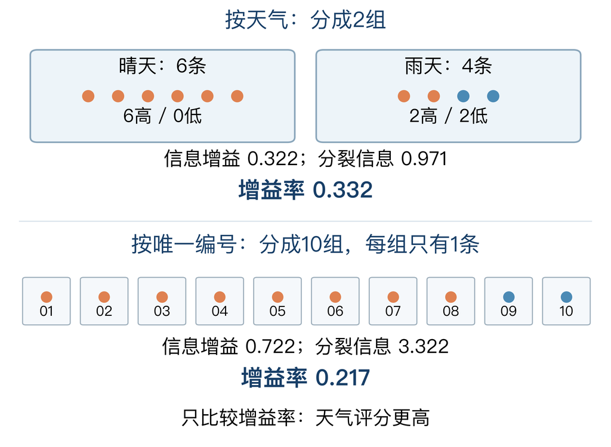

```python
ratio_labels = np.array([1] * 8 + [0] * 2)
ratio_groups = {"天气": [ratio_labels[:6], ratio_labels[6:]],
                "唯一编号": [ratio_labels[i:i+1] for i in range(len(ratio_labels))]}
ratio_rows = []
for name, groups in ratio_groups.items():
    weights = np.array([len(group) / len(ratio_labels) for group in groups])
    child_entropy = sum(weight * node_entropy(group) for weight, group in zip(weights, groups))
    gain = node_entropy(ratio_labels) - child_entropy
    # 分母只看各分支人数的比例，不使用分支内的类别比例。
    split_info = -np.sum(weights * np.log2(weights))
    ratio_rows.append({"分组特征": name, "分支数": len(groups), "信息增益": gain,
                       "分裂信息": split_info,
                       "增益率": gain / split_info if split_info > 0 else np.nan})
display(pd.DataFrame(ratio_rows).round(6))
class_plots.gain_ratio_example(ASSETS / "l7-gain-ratio-example.svg")
display(Image(filename=str(ASSETS / "l7-gain-ratio-example.png")))
```

### 同一批UCI数据：Gini与熵可能选择不同阈值

Gini用类别比例的平方评分，熵用负对数评分，都鼓励节点类别集中。以叶内比例预测概率时，它们分别联系概率平方误差与对数损失。`entropy`与`log_loss`在sklearn分类树中采用同一Shannon熵准则；两者均使用log₂，与本节手算一致。注意，独立评价函数`sklearn.metrics.log_loss`使用ln，数值相差一个正常数。

下面保持相同数据、深度与叶子样本数设置，比较根分裂；不能只凭训练结果宣称哪种准则更优。错分率用于前面的动机对照，不是sklearn可选的分类树切分准则。

参考：[sklearn分类准则](https://scikit-learn.org/stable/modules/tree.html#classification-criteria)。

```python
criterion_roots = []
for criterion in ["gini", "entropy", "log_loss"]:
    candidate = DecisionTreeClassifier(criterion=criterion, max_depth=demand_tree.max_depth,
                                      min_samples_leaf=20, random_state=42)
    candidate.fit(X_demand, demand_y)
    root_column = demand_features[candidate.tree_.feature[0]]
    criterion_roots.append({"准则": criterion, "根特征": root_column,
                            "根阈值": candidate.tree_.threshold[0]})
display(pd.DataFrame(criterion_roots).round(6))
```

|  | 准则 | 根特征 | 根阈值 |
| --- | --- | --- | --- |
| 0 | gini | temp | 0.389546 |
| 1 | entropy | temp | 0.340834 |
| 2 | log_loss | temp | 0.340834 |

### 观察分类边界：Gini、IG与GR

固定前491天、`temp`和`hum`、高需求标签`cnt>=4000`，三者都按阈值二分，最大深度7、叶子最少1条。

Gini与信息增益IG使用sklearn的`gini`和`entropy`。GR需要自行计算：每个节点遍历合法阈值，比较$\mathrm{GR}=\mathrm{IG}/\mathrm{SplitInfo}$。

**范围**：下面的GR只演示比率评分，不含完整C4.5的信息增益预筛、连续阈值校正及剪枝。因此比较的是评分产生的区域，不能把它命名为完整C4.5，也不能只看训练边界判断谁泛化更好。

```python
# 三种评分共享输入与复杂度限制。
boundary_models = {}
for name, criterion in [("Gini", "gini"), ("IG", "entropy")]:
    model = DecisionTreeClassifier(criterion=criterion, max_depth=7,
                                   min_samples_leaf=1, random_state=42)
    model.fit(X_demand, demand_y)
    boundary_models[name] = model
boundary_X = X_demand.to_numpy()
boundary_y = np.asarray(demand_y)
```

```python
# 候选仍是相邻不同特征值的中点，返回每个合法候选的GR。
def gr_candidates(rows):
    candidates = []
    for column in range(boundary_X.shape[1]):
        values = np.unique(boundary_X[rows, column])
        for threshold in (values[:-1] + values[1:]) / 2:
            mask = boundary_X[rows, column] <= threshold
            left, right = rows[mask], rows[~mask]
            if min(len(left), len(right)) < 1:
                continue  # 左右子节点都必须非空。
            fraction = len(left) / len(rows)
            gain = (node_entropy(boundary_y[rows]) - fraction * node_entropy(boundary_y[left])
                    - (1 - fraction) * node_entropy(boundary_y[right]))
            split_info = -fraction * np.log2(fraction) - (1-fraction) * np.log2(1-fraction)
            candidates.append((gain / split_info, column, threshold, left, right))
    return candidates
```

```python
# 在每个节点选择GR最大的候选，再对子节点重复，最多切分7层。
def fit_gr_node(rows, depth=0):
    node = {"prediction": int(boundary_y[rows].mean() > .5)}
    if depth >= 7 or len(np.unique(boundary_y[rows])) == 1:
        return node
    candidates = gr_candidates(rows)
    if not candidates:
        return node
    score, column, threshold, left, right = max(candidates, key=lambda item: item[0])
    if score <= 0:
        return node
    node.update(column=column, threshold=float(threshold),
                left=fit_gr_node(left, depth+1), right=fit_gr_node(right, depth+1))
    return node

gr_tree = fit_gr_node(np.arange(len(boundary_y)))
print("GR根条件：", demand_features[gr_tree["column"]], "≤", round(gr_tree["threshold"], 6))
```

```
GR根条件： temp ≤ 0.340834
```

```python
# 每个新输入沿树逐层判断，到叶子后返回该叶子的多数类。
def predict_gr(inputs, node=gr_tree):
    if "column" not in node:
        return np.full(len(inputs), node["prediction"], dtype=int)
    left = inputs[:, node["column"]] <= node["threshold"]
    prediction = np.empty(len(inputs), dtype=int)
    prediction[left] = predict_gr(inputs[left], node["left"])
    prediction[~left] = predict_gr(inputs[~left], node["right"])
    return prediction

bounds = [(max(0, X_demand[f].min()-.03), min(1, X_demand[f].max()+.03)) for f in demand_features]
mesh_temp, mesh_hum = np.meshgrid(np.linspace(*bounds[0], 401), np.linspace(*bounds[1], 401))
mesh_inputs = pd.DataFrame({"temp": mesh_temp.ravel(), "hum": mesh_hum.ravel()})
```

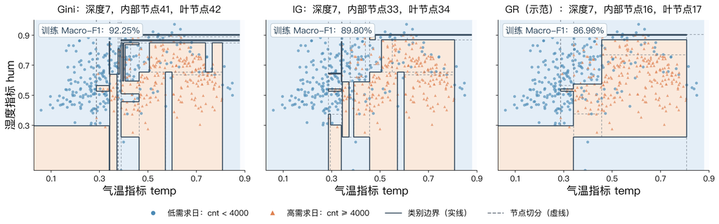

```python
from sklearn.metrics import f1_score
boundary_training_predictions = [model.predict(X_demand) for model in boundary_models.values()]
boundary_training_predictions.append(predict_gr(X_demand.to_numpy()))
boundary_macro_f1 = [f1_score(demand_y, pred, average="macro") for pred in boundary_training_predictions]
boundary_predictions = [model.predict(mesh_inputs) for model in boundary_models.values()]
boundary_predictions.append(predict_gr(mesh_inputs.to_numpy()))
boundary_captions = ["Gini\n首次切分：temp ≤ 0.390", "信息增益 IG\n首次切分：temp ≤ 0.341", "增益率 GR（评分示范）\n首次切分：temp ≤ 0.341"]
class_plots.criterion_boundaries(X_demand, demand_y, mesh_temp, mesh_hum,
    boundary_predictions, boundary_captions, ASSETS / "l7-classification-boundaries.svg",
    trees=[*boundary_models.values(), gr_tree], macro_f1=boundary_macro_f1)
display(Image(filename=str(ASSETS / "l7-classification-boundaries.png")))
# 核对图中阈值确实来自拟合结果，而非手工指定分界。
assert np.isclose(boundary_models["Gini"].tree_.threshold[0], .3895455)
assert 0 < gr_tree["threshold"] < 1
_ = (ASSETS / "l7-classification-boundaries.json").write_text(json.dumps({
    "rows": len(boundary_y), "features": demand_features, "max_depth": 7,
    "min_samples_leaf": 1, "training_macro_f1": dict(zip(["Gini", "IG", "GR"], boundary_macro_f1)), "gr_scope": "ratio-only binary split demo, not full C4.5",
    "root_thresholds": {name: float(m.tree_.threshold[0]) for name, m in boundary_models.items()},
    "gr_tree": gr_tree}, ensure_ascii=False, indent=2))
```

**观察**：Gini与IG切出更多局部小区域，GR在本例中的分区较少。不同评分不仅改变切分位置，也影响最终树的结构。

### 算法家族与sklearn实现

前面比较的是**一次切分的评分**。建树算法还规定分支结构、停止条件和剪枝方式。

**Quinlan的路线：ID3（1979） → C4.5（1991） → C5.0（1997）**，主要面向分类。**Breiman等人的CART（1984）**同时支持分类与回归。

| 算法 | 任务 | 主要切分思路 | 需要记住的区别 |
| --- | --- | --- | --- |
| [ID3（1979） ↗](https://esmeml.github.io/01-lectures/treesHB.pdf#page=1) | 分类 | 选择信息增益（IG）最大的特征 | 经典形式处理离散特征，可按不同取值一次分出多个分支 |
| [C4.5（1991） ↗](https://www.cs.cmu.edu/afs/cs/project/jair/pub/volume4/quinlan96a.pdf) | 分类 | 筛选信息增益后比较增益率 | 能为连续特征自动选择切分阈值，也支持缺失值处理与剪枝 |
| [C5.0（1997） ↗](https://topepo.github.io/C5.0/reference/C5.0.html) | 分类 | 延续并改进C4.5体系 | 可生成树或规则集，可结合Boosting，并设置不同类型错误的代价 |
| [CART（1984） ↗](https://scikit-learn.org/stable/modules/tree.html#tree-algorithms-id3-c4-5-c5-0-and-cart) | 分类＋回归 | 分类常用Gini，回归常用平方误差 | 递归二路切分，经典方法使用代价复杂度剪枝 |

ID3：Iterative Dichotomiser 3。CART：Classification and Regression Trees（分类与回归树）。

**本课采用sklearn的优化CART实现**。用[DecisionTreeRegressor ↗](https://scikit-learn.org/stable/modules/generated/sklearn.tree.DecisionTreeRegressor.html)预测租赁次数，用[DecisionTreeClassifier ↗](https://scikit-learn.org/stable/modules/generated/sklearn.tree.DecisionTreeClassifier.html)预测高、低需求。

一棵树仍可能随训练样本变化而波动。接下来用重抽样训练多棵树，再汇总预测，观察能否减小波动。

## 13. 单棵树与Bagging：同一批新日期的预测

**自助聚合（Bootstrap Aggregating, Bagging）**：对训练记录有放回重抽样，分别训练基模型，再对回归预测取平均。

使用8个输入：`temp, hum, windspeed, workingday, holiday, season, mnth, yr`。前491天训练，随后120天验证。天气按已观测条件使用，不能据此假设提前知道未来天气。

只用气温会遗漏年份与其他影响因素，使单树和平均预测都偏低。这里补足输入，用默认未剪枝回归树演示高方差基学习器，再对照单树与10棵树的平均。两者共享输入和划分，基树`min_samples_leaf=1`、`max_depth=None`、随机种子42。

图中按时间展示验证段前30天，便于看清曲线。MAE仍按全部120天计算，不按图中日期挑选最优模型。这是开发演示，不是独立最终测试成绩。

```python
# 使用8个天气与日期输入，只在前491天拟合。
bagging_features = ["temp", "hum", "windspeed", "workingday", "holiday", "season", "mnth", "yr"]
bagging_input = fit_frame[bagging_features]
bagging_target = fit_frame["cnt"]
bagging_valid = dev_valid[bagging_features]
bagging_actual = dev_valid["cnt"]
single_bagging_baseline = DecisionTreeRegressor(random_state=42)
single_bagging_baseline.fit(bagging_input, bagging_target)
bagging_models = {"单树": single_bagging_baseline}
```

```python
# 10棵默认未剪枝树，除重抽与平均外，基树设置与单树一致。
bagging_ten = BaggingRegressor(
    estimator=DecisionTreeRegressor(random_state=42),
    n_estimators=10, random_state=42, n_jobs=1)
bagging_ten.fit(bagging_input, bagging_target)
bagging_models["Bagging 10棵"] = bagging_ten

bagging_validation_predictions = {name: model.predict(bagging_valid)
                                  for name, model in bagging_models.items()}
bagging_mae = {name: float(mean_absolute_error(bagging_actual, pred))
               for name, pred in bagging_validation_predictions.items()}
display(pd.DataFrame({"验证MAE（次数）": bagging_mae}).round(1))
```

|  | 验证MAE（次数） |
| --- | --- |
| 单树 | 976.2 |
| Bagging 10棵 | 763.3 |

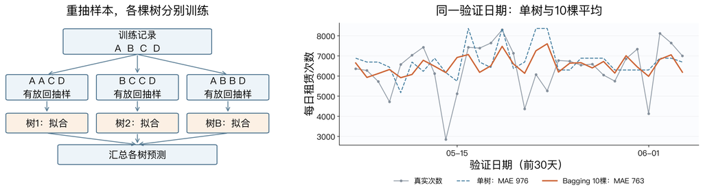

```python
# 固定显示验证段前30天，误差由全部120天计算。
bagging_comparison = {
    "valid_dates": dev_valid.dteday.dt.strftime("%Y-%m-%d").tolist(),
    "valid_y": bagging_actual.tolist(), "mae": bagging_mae, "display_n": 30,
    "valid_predictions": {name: pred.tolist() for name, pred in bagging_validation_predictions.items()},
    "features": bagging_features, "train_rows": len(fit_frame), "valid_rows": len(dev_valid),
    "min_samples_leaf": 1, "max_depth": None, "random_state": 42}
plots.bagging_overview(path=ASSETS / "l7-bagging-overview.svg", comparison=bagging_comparison)
display(Image(filename=str(ASSETS / "l7-bagging-overview.png")))
_ = (ASSETS / "l7-bagging-comparison.json").write_text(json.dumps(bagging_comparison, ensure_ascii=False, indent=2))
```

### 不只看一次误差：换一些训练记录，预测会波动多少？

重复20次，每次随机保留80%的训练记录（392条），单树与Bagging用相同子集。模型种子仍固定42，只改变训练记录，验证输入始终不变。

对每个验证输入，计算20次预测的标准差，再对120个输入取平均。这个数描述对训练记录扰动的敏感性，不是预测误差，也不是时间序列置信区间。

```python
# 只扰动训练记录，单树与Bagging共享每次抽到的子集。
stability_rng = np.random.default_rng(42)
stability_predictions = {"单树": [], "Bagging 10棵": []}
for repetition in range(20):
    selected = np.sort(stability_rng.choice(len(fit_frame), int(.8*len(fit_frame)), replace=False))
    subset_X, subset_y = bagging_input.iloc[selected], bagging_target.iloc[selected]
    single = DecisionTreeRegressor(random_state=42)
    ensemble = BaggingRegressor(estimator=DecisionTreeRegressor(random_state=42),
                               n_estimators=10, random_state=42, n_jobs=1)
    for name, model in [("单树", single), ("Bagging 10棵", ensemble)]:
        model.fit(subset_X, subset_y)
        stability_predictions[name].append(model.predict(bagging_valid))
```

```python
# 先在每个固定输入上计算20次预测的STD和方差，再对120个输入平均。
bagging_std_by_input = {name: np.std(predictions, axis=0, ddof=0)
                        for name, predictions in stability_predictions.items()}
bagging_var_by_input = {name: np.var(predictions, axis=0, ddof=0)
                        for name, predictions in stability_predictions.items()}
bagging_stability = {name: float(values.mean()) for name, values in bagging_std_by_input.items()}
bagging_mean_variance = {name: float(values.mean()) for name, values in bagging_var_by_input.items()}
display(pd.DataFrame({"平均预测STD（次数）": bagging_stability,
                      "平均预测方差（次数²）": bagging_mean_variance}).round(2))
bagging_more_stable = int(np.sum(bagging_std_by_input["Bagging 10棵"] < bagging_std_by_input["单树"]))
print(f"Bagging预测STD更小的固定输入：{bagging_more_stable}/120")
bagging_comparison["stability"] = {"repeats": 20, "training_subset_rows": 392,
    "mean_prediction_std": bagging_stability, "mean_prediction_variance": bagging_mean_variance,
    "smaller_std_inputs": bagging_more_stable, "model_seed": 42, "subset_seed": 42}
(ASSETS / "l7-bagging-comparison.json").write_text(json.dumps(bagging_comparison, ensure_ascii=False, indent=2))
_ = (ASSETS / "l7-bagging-stability.json").write_text(json.dumps({
    **bagging_comparison["stability"], "ddof": 0, "fixed_validation_rows": 120,
    "predictions_by_repeat": {name: np.asarray(pred).tolist() for name, pred in stability_predictions.items()},
    "std_by_input": {name: pred.tolist() for name, pred in bagging_std_by_input.items()},
    "variance_by_input": {name: pred.tolist() for name, pred in bagging_var_by_input.items()}}, ensure_ascii=False, indent=2))
```

|  | 平均预测STD（次数） | 平均预测方差（次数²） |
| --- | --- | --- |
| 单树 | 611.26 | 445691.67 |
| Bagging 10棵 | 273.69 | 85459.14 |

```
Bagging预测STD更小的固定输入：117/120
```

## 14. 随机森林：增加特征随机性

候选输入为 `temp, hum, windspeed, workingday, holiday, season, mnth, yr`。这是给定当天日历和天气信息后的条件估计；它没有预测未来天气的能力。

```python
forest_features = ["temp", "hum", "windspeed", "workingday", "holiday", "season", "mnth", "yr"]
```

### 为什么Bagging之后还要随机候选特征？

若某个特征特别强，即使Bootstrap样本不同，许多树也可能在顶部选同一特征。树的预测仍可能相似，平均的收益受到相关性限制。RF在每个节点随机限制候选特征，目标是降低相关性，同时保留单树预测能力。

依据：[ISL第2版§8.2.2，印刷343–345页](https://www.karlin.mff.cuni.cz/~pesta/NMFM334/StatLearning/Book2nd/ISLRv2_website.pdf#page=352)、[Breiman《Random Forests》§3](https://www.stat.berkeley.edu/~breiman/randomforest2001.pdf#page=7)。下面用同一UCI数据比较：同样50棵树、节点至少20条才尝试切分、叶子至少5条、种子42，只将`max_features`从1.0改为0.7。使用同一RandomForestRegressor接口作控制，1.0对应全部8项候选的Bagging式基线，0.7通常对应每节点5项。

```python
# 用同一实现、相同Bootstrap随机种子，只改变节点候选特征数量。
rf_candidate_models = {}
for name, fraction in [("全部8候选", 1.0), ("每节点5候选", .7)]:
    model = RandomForestRegressor(n_estimators=50, max_features=fraction,
                                 min_samples_leaf=5, min_samples_split=20, random_state=42, n_jobs=1)
    model.fit(fit_frame[forest_features], y_fit)
    rf_candidate_models[name] = model

# 两组每棵树的抽样记录一致，确保对照没有同时改变Bootstrap样本。
assert all(np.array_equal(a, b) for a, b in zip(
    rf_candidate_models["全部8候选"].estimators_samples_,
    rf_candidate_models["每节点5候选"].estimators_samples_))
```

|  | 全部8候选 | 每节点5候选 |
| --- | --- | --- |
| temp | 50 | 32 |
| hum | 0 | 1 |
| windspeed | 0 | 0 |
| workingday | 0 | 0 |
| holiday | 0 | 0 |
| season | 0 | 14 |
| mnth | 0 | 3 |
| yr | 0 | 0 |

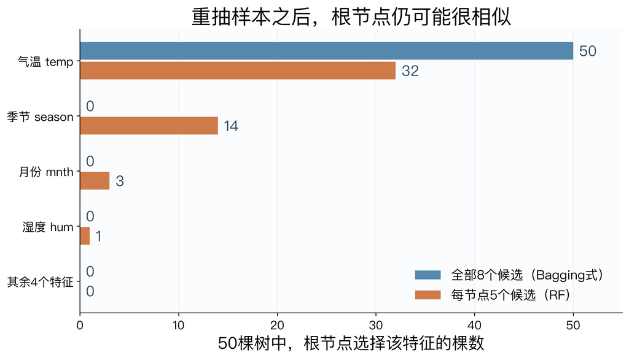

|  | 验证MAE（次数） |
| --- | --- |
| 全部8候选 | 760.8 |
| 每节点5候选 | 836.0 |

```python
import rf_story as rf_plots
rf_root_counts = pd.DataFrame({
    name: np.bincount([tree.tree_.feature[0] for tree in model.estimators_], minlength=8)
    for name, model in rf_candidate_models.items()}, index=forest_features)
display(rf_root_counts)
rf_plots.root_choices(rf_root_counts, ASSETS / "l7-rf-root-choices.svg")
display(Image(filename=str(ASSETS / "l7-rf-root-choices.png")))
# 评分只作开发观察，不预设更多随机性一定改善误差。
rf_candidate_mae = {name: float(mean_absolute_error(dev_valid.cnt, model.predict(dev_valid[forest_features])))
                    for name, model in rf_candidate_models.items()}
display(pd.DataFrame({"验证MAE（次数）": rf_candidate_mae}).round(1))
```

### 每个节点重新选候选，单棵树继续递归

先为每棵树Bootstrap抽记录；在根节点与各个子节点分别随机抽候选特征，搜索最佳特征和阈值，再对左右子节点重复。到停止条件才形成叶子。

`n_estimators`控制森林树数，`max_depth`控制单树深度上限，`min_samples_split`决定节点是否能尝试切分，`min_samples_leaf`要求两边叶子都足够大。每完成一次切分只改变当前树的节点，不自动增加一棵树。

回归森林平均各树的数值预测。经典分类森林对各树预测类别多数投票；sklearn分类森林先平均各树类别概率，再选平均概率最大的类，两者结果可能不同。[实现说明](https://scikit-learn.org/stable/modules/ensemble.html#random-forests)。

下面的递归图是概念示意，不冒充sklearn内部候选集合记录。随后直接读取真实森林的每棵树深度、叶子数和用过的特征。

本例同时设置 `min_samples_split=20` 与 `min_samples_leaf=5`：15条记录的节点不能尝试切分；20条记录的节点可以尝试，但18+2的切分不合法，15+5满足样本数要求。

|  | 树编号 | 实际深度 | 叶子数 | 用过的特征数 |
| --- | --- | --- | --- | --- |
| 0 | 1 | 12 | 27 | 6 |
| 1 | 2 | 11 | 26 | 7 |
| 2 | 3 | 10 | 28 | 7 |
| 3 | 4 | 11 | 31 | 7 |
| 4 | 5 | 12 | 26 | 7 |
| 5 | 6 | 9 | 26 | 7 |
| 6 | 7 | 9 | 26 | 7 |
| 7 | 8 | 13 | 29 | 7 |
| 8 | 9 | 8 | 27 | 7 |
| 9 | 10 | 13 | 28 | 7 |

```
森林树数： 50
深度范围： 8 13
叶子数范围： 23 32
```

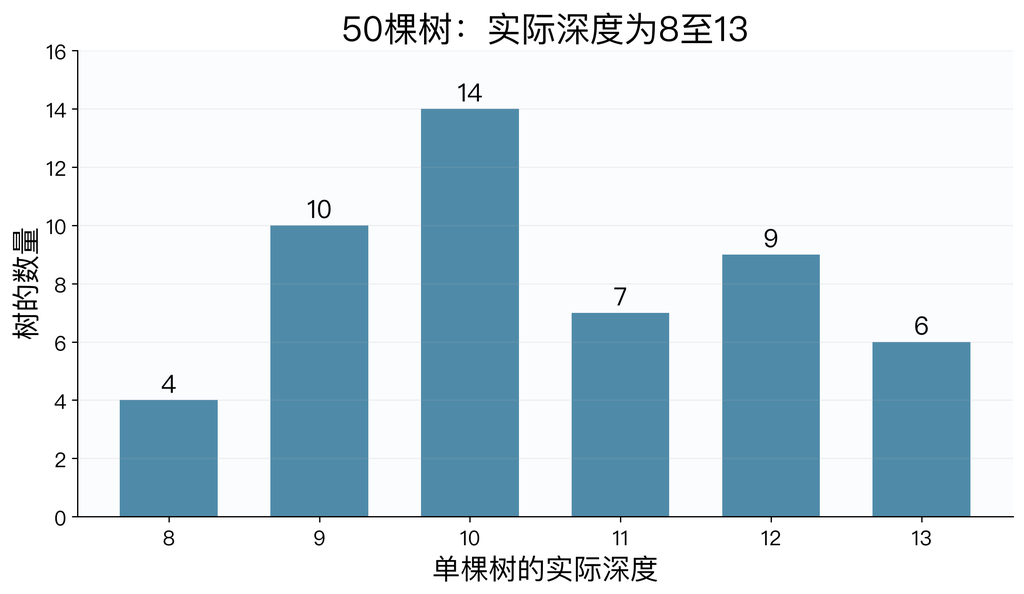

```python
rf_current = rf_candidate_models["每节点5候选"]
rf_tree_structure = pd.DataFrame([
    {"树编号": index+1, "实际深度": tree.get_depth(), "叶子数": tree.get_n_leaves(),
     "用过的特征数": len(np.unique(tree.tree_.feature[tree.tree_.feature >= 0]))}
    for index, tree in enumerate(rf_current.estimators_)])
display(rf_tree_structure.head(10))
print("森林树数：", len(rf_current.estimators_))
print("深度范围：", rf_tree_structure["实际深度"].min(), rf_tree_structure["实际深度"].max())
print("叶子数范围：", rf_tree_structure["叶子数"].min(), rf_tree_structure["叶子数"].max())
rf_plots.depth_histogram(rf_tree_structure["实际深度"], ASSETS / "l7-rf-depths.svg")
display(Image(filename=str(ASSETS / "l7-rf-depths.png")))
```

```python
# 同一输入上，森林的回归输出等于全部树预测的平均。
forest = rf_current
forest_row = fit_frame.iloc[[150]][forest_features]
forest_single = np.array([tree.predict(forest_row.to_numpy())[0] for tree in forest.estimators_])
forest_average = float(forest.predict(forest_row)[0])
display(pd.DataFrame({"树编号": np.arange(1, 51), "预测租赁次数": forest_single}).head(10).round(1))
print(f"全部50棵树平均：{forest_single.mean():,.2f}；森林predict：{forest_average:,.2f}。")
```

|  | 树编号 | 预测租赁次数 |
| --- | --- | --- |
| 0 | 1 | 4723.8 |
| 1 | 2 | 4998.5 |
| 2 | 3 | 4591.7 |
| 3 | 4 | 4752.5 |
| 4 | 5 | 3887.8 |
| 5 | 6 | 4198.0 |
| 6 | 7 | 4412.5 |
| 7 | 8 | 4763.4 |
| 8 | 9 | 4543.7 |
| 9 | 10 | 4626.4 |

```
全部50棵树平均：4,416.41；森林predict：4,416.41。
```

```python
# 递归机制图与简化相关性公式，仅负责解释机制。
rf_plots.recursive_tree(ASSETS / "l7-rf-recursion.svg")
rf_plots.correlation_formula(ASSETS / "l7-rf-correlation-formula.svg")
_ = (ASSETS / "l7-rf-story.json").write_text(json.dumps({
    "features": forest_features, "train_rows": len(fit_frame), "valid_rows": len(dev_valid),
    "n_estimators": 50, "min_samples_leaf": 5, "min_samples_split": 20, "random_state": 42,
    "root_counts": rf_root_counts.to_dict(), "validation_mae": rf_candidate_mae,
    "tree_structure": rf_tree_structure.to_dict(orient="records"),
    "scope": "same bootstrap samples, only max_features differs; schematic is conceptual"},
    ensure_ascii=False, indent=2))
```

**观察**：全部8候选时，50棵树根节点都选`temp`；每节点5候选时，根节点选择分散。它说明结构变化，不直接证明误差必降。本段验证中RF的MAE反而较高，与“降低相关性也可能削弱单树”的权衡一致。根节点频次不是误差相关系数。

公式是等方差、等相关随机变量平均的简化情形，不是任意RF验证误差的精确公式。特别要区分：本例的“每节点5候选”不限制整棵树只用5个特征，也不限制树只有一层。

## 15. 随机森林：树数与候选特征数怎样选？

上一节区分树数与单树停止条件。这里固定 `min_samples_split=20`、`min_samples_leaf=5`、`max_depth=None`，同时比较树数与节点候选特征数。仍使用8个输入字段，改变的是每个节点能参与竞争的候选数，不是删除输入列。

sklearn回归默认 `max_features=1.0`（本例8个），分类默认 `"sqrt"`（本例2个）。回归也值得验证更小的候选范围，例如文献常见的约三分之一。本例比较整数2、3、5、8，其中3也对应 `"log2"`，5延续前面的演示配置。默认值和经验值均不保证最优。[sklearn参数说明](https://scikit-learn.org/stable/modules/ensemble.html#parameters)。

使用相同3折时间顺序验证及种子13、42、73，比较28组候选。末120天原预留不参与。图显示9项误差的均值，跨折和种子的标准差放在表中。

```python
# 输入始终是8列，只改变每节点候选特征数与森林树数。
sizes = [1, 5, 10, 30, 50, 100, 200]
feature_counts = [2, 3, 5, 8]
tuning_rows = []
for fold, (tr, va) in enumerate(tscv.split(development), start=1):
    Xtr, Xva = development.iloc[tr][forest_features], development.iloc[va][forest_features]
    for seed in (13, 42, 73):
        for count in feature_counts:
            for trees in sizes:
                model = RandomForestRegressor(n_estimators=trees, max_features=count,
                    min_samples_split=20, min_samples_leaf=5, random_state=seed, n_jobs=1)
                model.fit(Xtr, development.iloc[tr]["cnt"])
                mse = mean_squared_error(development.iloc[va]["cnt"], model.predict(Xva))
                tuning_rows.append({"候选特征数": count, "树数": trees,
                                    "折": fold, "种子": seed, "MSE": float(mse)})
rf_tuning = pd.DataFrame(tuning_rows)
```

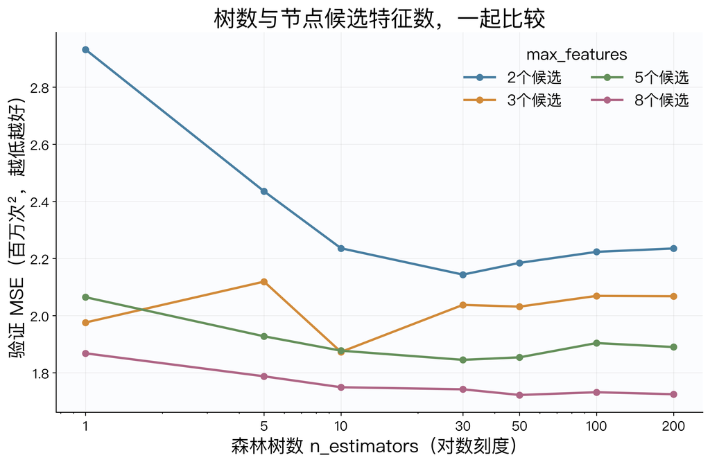

|  | 候选特征数 | 树数 | MSE均值 | MSE标准差 |
| --- | --- | --- | --- | --- |
| 0 | 2 | 1 | 2931859.0 | 1687768.0 |
| 1 | 2 | 5 | 2435321.0 | 1296205.0 |
| 2 | 2 | 10 | 2235975.0 | 1110421.0 |
| 3 | 2 | 30 | 2143723.0 | 1086297.0 |
| 4 | 2 | 50 | 2184832.0 | 1095555.0 |
| 5 | 2 | 100 | 2223379.0 | 1125963.0 |
| 6 | 2 | 200 | 2235252.0 | 1114452.0 |
| 7 | 3 | 1 | 1976010.0 | 1166971.0 |
| 8 | 3 | 5 | 2119188.0 | 1142676.0 |
| 9 | 3 | 10 | 1873074.0 | 1160950.0 |
| 10 | 3 | 30 | 2037728.0 | 1128975.0 |
| 11 | 3 | 50 | 2031611.0 | 1096344.0 |
| 12 | 3 | 100 | 2069195.0 | 1129872.0 |
| 13 | 3 | 200 | 2068006.0 | 1112869.0 |
| 14 | 5 | 1 | 2064677.0 | 1397739.0 |
| 15 | 5 | 5 | 1927757.0 | 1118948.0 |
| 16 | 5 | 10 | 1877373.0 | 1106304.0 |
| 17 | 5 | 30 | 1845300.0 | 1109873.0 |
| 18 | 5 | 50 | 1854138.0 | 1085793.0 |
| 19 | 5 | 100 | 1904107.0 | 1095102.0 |
| 20 | 5 | 200 | 1890168.0 | 1074570.0 |
| 21 | 8 | 1 | 1868222.0 | 957438.0 |
| 22 | 8 | 5 | 1787681.0 | 1006775.0 |
| 23 | 8 | 10 | 1749386.0 | 1053996.0 |
| 24 | 8 | 30 | 1742182.0 | 1045036.0 |
| 25 | 8 | 50 | 1722339.0 | 1050844.0 |
| 26 | 8 | 100 | 1731976.0 | 1045462.0 |
| 27 | 8 | 200 | 1724960.0 | 1035506.0 |

```python
# 每个配置有3折×3种子共9项，不把这些波动称作置信区间。
rf_tuning_summary = rf_tuning.groupby(["候选特征数", "树数"], as_index=False).agg(
    MSE均值=("MSE", "mean"), MSE标准差=("MSE", lambda values: np.std(values, ddof=0)))
rf_plots.tuning_curves(rf_tuning_summary, ASSETS / "l7-bike-forest-size.svg")
display(Image(filename=str(ASSETS / "l7-bike-forest-size.png")))
display(rf_tuning_summary.round(0))
```

```python
# 显示候选中均值最低的一组，保留逐折结果，避免只看汇总名次。
rf_tuning_best = rf_tuning_summary.loc[rf_tuning_summary["MSE均值"].idxmin()]
print("本轮候选中最低均值配置：", rf_tuning_best.to_dict())
rf_best_rows = rf_tuning[(rf_tuning["候选特征数"] == rf_tuning_best["候选特征数"]) &
                         (rf_tuning["树数"] == rf_tuning_best["树数"])]
display(rf_best_rows)
# 保留5候选这条曲线，兼容章末原结果汇总的变量名。
size_scores = {n: rf_tuning.loc[(rf_tuning["候选特征数"] == 5) &
    (rf_tuning["树数"] == n), "MSE"].tolist() for n in sizes}
size_means = [float(np.mean(size_scores[n])) for n in sizes]
size_stds = [float(np.std(size_scores[n])) for n in sizes]
_ = (ASSETS / "l7-rf-tuning.json").write_text(json.dumps({
    "features": forest_features, "fixed_params": {"min_samples_split": 20,
    "min_samples_leaf": 5, "max_depth": None, "bootstrap": True},
    "seeds": [13, 42, 73], "splitter": "TimeSeriesSplit(n_splits=3)",
    "sizes": sizes, "feature_counts": feature_counts,
    "per_fold_seed": rf_tuning.to_dict(orient="records"),
    "summary": rf_tuning_summary.to_dict(orient="records"),
    "best_in_candidates": rf_tuning_best.to_dict()}, ensure_ascii=False, indent=2))
```

```
本轮候选中最低均值配置： {'候选特征数': 8.0, '树数': 50.0, 'MSE均值': 1722339.0944738304, 'MSE标准差': 1050843.8763483285}
```

|  | 候选特征数 | 树数 | 折 | 种子 | MSE |
| --- | --- | --- | --- | --- | --- |
| 25 | 8 | 50 | 1 | 13 | 6.988873e+05 |
| 53 | 8 | 50 | 1 | 42 | 7.056315e+05 |
| 81 | 8 | 50 | 1 | 73 | 6.891127e+05 |
| 109 | 8 | 50 | 2 | 13 | 3.165668e+06 |
| 137 | 8 | 50 | 2 | 42 | 3.127836e+06 |
| 165 | 8 | 50 | 2 | 73 | 3.205289e+06 |
| 193 | 8 | 50 | 3 | 13 | 1.328360e+06 |
| 221 | 8 | 50 | 3 | 42 | 1.250341e+06 |
| 249 | 8 | 50 | 3 | 73 | 1.329926e+06 |

**怎样选择**：先比较不同候选特征数对应的验证误差，再看增加树数后是否仍有明显收益。误差接近时，可结合各折表现及资源成本选择。候选越少，树可能更有差异，但单树也可能变弱，误差并不保证下降。

**其他可调参数**：`min_samples_leaf`可试1、5、10、20，`min_samples_split`可试2、10、20、40，`max_depth`可试None、5、10。这些是教学候选范围，需要结合样本量缩放，不是官方最佳参数。本图只比较树数与候选特征数，未搜索这些单树参数，因此不能称为全部参数的最优解。

后续机制说明使用固定配置；这里的选参结果只用于开发观察。

### 固定其他参数，分别看五个参数的影响

上一组同时比较树数与候选特征数。这一组每次只改一个参数，其余固定为上一页的基准：50棵树、每节点5候选、叶子至少5条、节点至少20条才尝试切分、深度不限。仍用同样8列输入、3折时间顺序划分与种子13、42、73。

同时记录训练MSE与验证MSE。训练误差降低只说明更能拟合已见记录，是否有助于新记录，要看验证曲线。原末120天不参与。

```python
# 每次只改变一项，其余保持基准配置。
rf_effects_base = dict(n_estimators=50, max_features=5, min_samples_leaf=5,
                       min_samples_split=20, max_depth=None, bootstrap=True)
rf_effects_values = {
    "n_estimators": [1, 5, 10, 30, 50, 100, 200],
    "max_features": [1, 2, 3, 5, 6, 8],
    "min_samples_leaf": [1, 3, 5, 10, 20, 40],
    "min_samples_split": [2, 5, 10, 20, 40, 80],
    "max_depth": [1, 2, 3, 5, 8, 12, None]}
```

```python
rf_effects_rows = []
for parameter, values in rf_effects_values.items():
    for order, value in enumerate(values):
        parameters = {**rf_effects_base, parameter: value}
        for fold, (tr, va) in enumerate(tscv.split(development), start=1):
            Xtr, Xva = development.iloc[tr][forest_features], development.iloc[va][forest_features]
            ytr, yva = development.iloc[tr]["cnt"], development.iloc[va]["cnt"]
            for seed in (13, 42, 73):
                model = RandomForestRegressor(**parameters, random_state=seed, n_jobs=1)
                model.fit(Xtr, ytr)
                rf_effects_rows.append({"参数": parameter, "档位": order,
                    "参数值": str(value), "折": fold, "种子": seed,
                    "训练MSE": float(mean_squared_error(ytr, model.predict(Xtr))),
                    "验证MSE": float(mean_squared_error(yva, model.predict(Xva)))})
rf_effects = pd.DataFrame(rf_effects_rows)
```

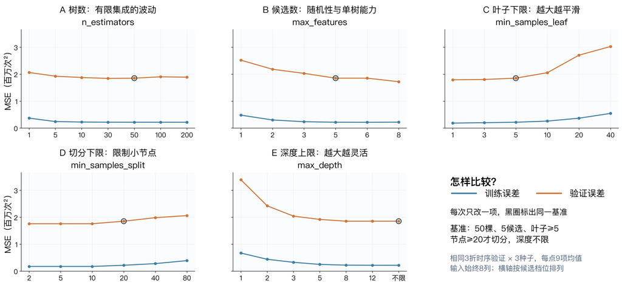

|  | 参数 | 档位 | 参数值 | 训练均值 | 验证均值 | 训练标准差 | 验证标准差 |
| --- | --- | --- | --- | --- | --- | --- | --- |
| 0 | max_depth | 0 | 1 | 671554.0 | 3391126.0 | 353384.0 | 2162888.0 |
| 1 | max_depth | 1 | 2 | 439483.0 | 2424130.0 | 206356.0 | 1209271.0 |
| 2 | max_depth | 2 | 3 | 327205.0 | 2041685.0 | 118139.0 | 1082308.0 |
| 3 | max_depth | 3 | 5 | 249396.0 | 1919756.0 | 63327.0 | 1090842.0 |
| 4 | max_depth | 4 | 8 | 222134.0 | 1853539.0 | 42891.0 | 1085704.0 |
| 5 | max_depth | 5 | 12 | 217875.0 | 1853942.0 | 38839.0 | 1085446.0 |
| 6 | max_depth | 6 | None | 217746.0 | 1854138.0 | 38712.0 | 1085793.0 |
| 7 | max_features | 0 | 1 | 480560.0 | 2521532.0 | 35247.0 | 1059418.0 |
| 8 | max_features | 1 | 2 | 301888.0 | 2184832.0 | 45405.0 | 1095555.0 |
| 9 | max_features | 2 | 3 | 237221.0 | 2031611.0 | 45852.0 | 1096344.0 |
| 10 | max_features | 3 | 5 | 217746.0 | 1854138.0 | 38712.0 | 1085793.0 |
| 11 | max_features | 4 | 6 | 215397.0 | 1853857.0 | 37716.0 | 1058300.0 |
| 12 | max_features | 5 | 8 | 220301.0 | 1722339.0 | 39764.0 | 1050844.0 |
| 13 | min_samples_leaf | 0 | 1 | 185585.0 | 1792403.0 | 30018.0 | 1101563.0 |
| 14 | min_samples_leaf | 1 | 3 | 202060.0 | 1805462.0 | 32440.0 | 1096034.0 |
| 15 | min_samples_leaf | 2 | 5 | 217746.0 | 1854138.0 | 38712.0 | 1085793.0 |
| 16 | min_samples_leaf | 3 | 10 | 260330.0 | 2057352.0 | 57829.0 | 1055835.0 |
| 17 | min_samples_leaf | 4 | 20 | 367461.0 | 2707494.0 | 105586.0 | 1405876.0 |
| 18 | min_samples_leaf | 5 | 40 | 545423.0 | 3029199.0 | 148985.0 | 1540419.0 |
| 19 | min_samples_split | 0 | 2 | 173641.0 | 1759066.0 | 28226.0 | 1093406.0 |
| 20 | min_samples_split | 1 | 5 | 173641.0 | 1759066.0 | 28226.0 | 1093406.0 |
| 21 | min_samples_split | 2 | 10 | 173641.0 | 1759066.0 | 28226.0 | 1093406.0 |
| 22 | min_samples_split | 3 | 20 | 217746.0 | 1854138.0 | 38712.0 | 1085793.0 |
| 23 | min_samples_split | 4 | 40 | 279210.0 | 1984612.0 | 44789.0 | 1047548.0 |
| 24 | min_samples_split | 5 | 80 | 389813.0 | 2061263.0 | 66852.0 | 1051047.0 |
| 25 | n_estimators | 0 | 1 | 370114.0 | 2064677.0 | 93000.0 | 1397739.0 |
| 26 | n_estimators | 1 | 5 | 242582.0 | 1927757.0 | 43275.0 | 1118948.0 |
| 27 | n_estimators | 2 | 10 | 225227.0 | 1877373.0 | 41356.0 | 1106304.0 |
| 28 | n_estimators | 3 | 30 | 218782.0 | 1845300.0 | 39736.0 | 1109873.0 |
| 29 | n_estimators | 4 | 50 | 217746.0 | 1854138.0 | 38712.0 | 1085793.0 |
| 30 | n_estimators | 5 | 100 | 217525.0 | 1904107.0 | 39473.0 | 1095102.0 |
| 31 | n_estimators | 6 | 200 | 216803.0 | 1890168.0 | 38642.0 | 1074570.0 |

```python
# 每点汇总相同3折×3种子，标准差保留在表中，不作为置信区间。
rf_effects_summary = rf_effects.groupby(["参数", "档位", "参数值"], as_index=False).agg(
    训练均值=("训练MSE", "mean"), 验证均值=("验证MSE", "mean"),
    训练标准差=("训练MSE", lambda values: np.std(values, ddof=0)),
    验证标准差=("验证MSE", lambda values: np.std(values, ddof=0)))
rf_plots.parameter_effects(rf_effects_summary, rf_effects_base,
                          ASSETS / "l7-rf-parameter-effects.svg")
display(Image(filename=str(ASSETS / "l7-rf-parameter-effects.png")))
display(rf_effects_summary.round(0))
_ = (ASSETS / "l7-rf-parameter-effects.json").write_text(json.dumps({
    "features": forest_features, "baseline": rf_effects_base, "candidates": rf_effects_values,
    "seeds": [13, 42, 73], "splitter": "TimeSeriesSplit(n_splits=3)",
    "design": "one factor at a time; fixed other parameters; development data only",
    "per_fold_seed": rf_effects.to_dict(orient="records"),
    "summary": rf_effects_summary.to_dict(orient="records")}, ensure_ascii=False, indent=2))
```

**怎样读图**：蓝线是训练误差，橙线是验证误差。黑圈标出同一基准配置。横轴按候选档位排列，间距不代表数值间距。所有子图共用纵轴，不能把训练曲线下降直接理解为泛化改善。

**参数会相互约束**：这里固定`min_samples_leaf=5`，切分后两侧各需至少5条，所以节点本来就至少需要10条。将`min_samples_split`设为2、5或10不会增加新的限制，这几组结果相同。设为20及以上才可能进一步改变树。

**max_features的起点**：回归比较全部特征的Bagging式基线与较小候选范围，再按验证结果选择；分类通常从`"sqrt"`开始。这些是可验证的起点，不是通用最佳值。

单参数曲线只能说明其余参数固定时的影响，不能由每张图各选一个最小值就声称得到联合最优。需要联合选参时，可使用第6讲的搜索方法，并保持时间顺序CV。

## 16. 提升法：从多树平均到逐轮修正

前面的Bagging和随机森林（RF）先训练多棵树，再汇总预测，主要降低**方差（Variance）**，让预测更稳定。

但如果这些树都把需求估得偏高，平均后仍可能偏高。假如要做一锅符合大众口味的炖菜，请几位厨子各自提出调味建议。若他们都偏爱辣，综合建议仍可能让菜过辣。这就是插画上方的情境：共同的偏差不保证因平均而消失。

能否让后来的树专门修正已有预测的不足？**提升法（Boosting）**逐轮训练新模型，把学到的修正加入已有预测，常用于减小**偏差（Bias）**。后一个模型依赖前面的结果。

插画下方先补清汤，再根据“略寡淡”的反馈补咸鲜：看当前结果，作下一次修正，目标食客群体保持不变。

本节采用**梯度提升树（Gradient Boosting Decision Trees, GBDT）**。平方误差回归中，用“真实值减当前预测”的残差描述不足；其他损失的修正目标不一定是普通残差。[sklearn说明](https://scikit-learn.org/stable/modules/ensemble.html#gradient-boosted-trees)。

**类比边界**：地域和口味为本例设定，地区差异不是Boosting定义，插画不代表UCI实验结果。Bias与Variance只是这里强调的主要作用，两类方法都可能同时影响偏差与方差。

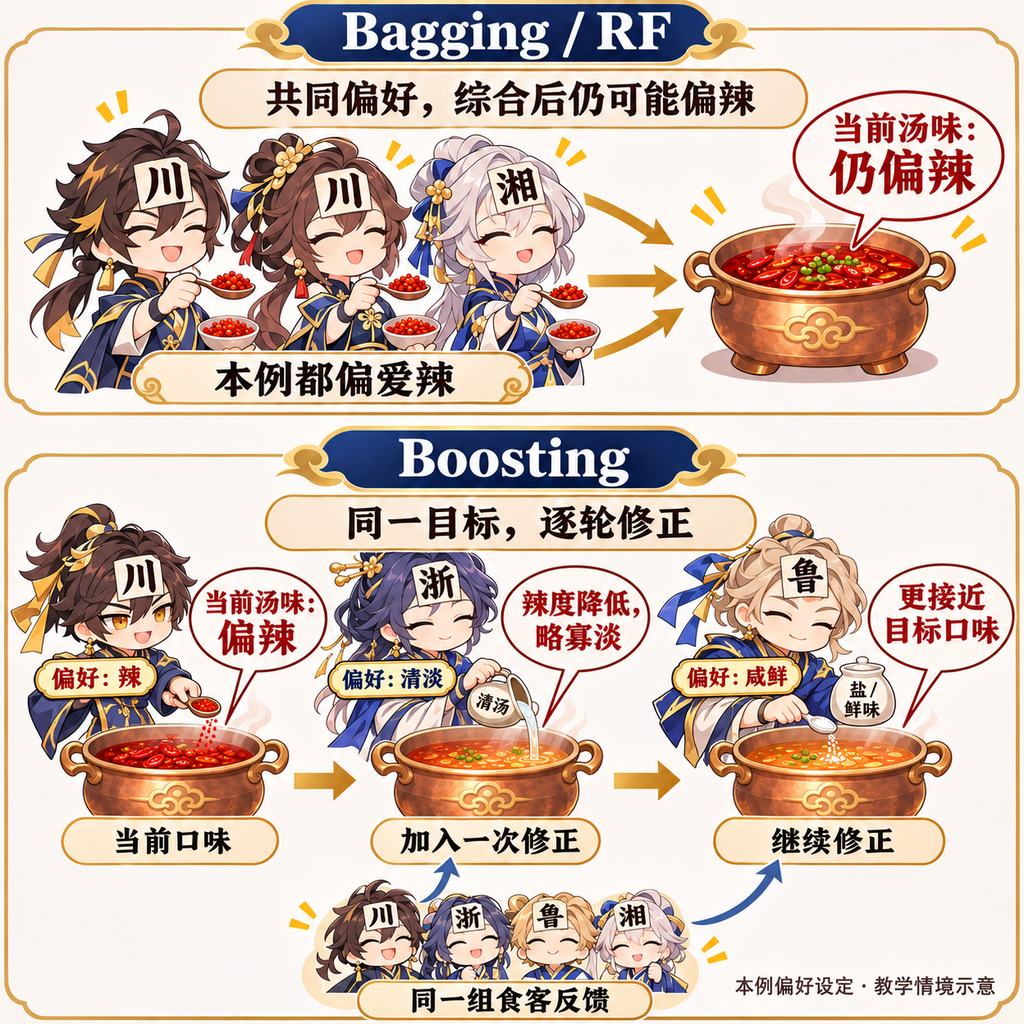

```python
# 调味插画用于解释共同偏好与逐轮修正，不是UCI实验输出。
display(Image(filename=str(ASSETS / "l7-boosting-cooking-v1.png")))
```

### 梯度提升回归（GBDT）：下一棵树拟合残差

上一页提出逐轮修正预测。新树学习什么？在共享单车的平方误差回归中，用真实租赁次数减去当前预测得到残差，作为下一棵树的学习目标。

其中，$i$ 表示样本，$m$ 表示当前轮次；$x_i$ 为输入，$y_i$ 为真实次数，$F_{m-1}(x_i)$ 为前 $m-1$ 轮的累计预测，$r_i^{(m)}$ 为本轮残差。

先用491天的平均租赁次数作为初始预测。新树仍以气温作为输入，学习这些残差。

下面两轮深度1回归树使用同一前491天拟合，学习率固定0.5。图和表摘6天展示，计算及与库实现的逐轮核对覆盖完整拟合段。

```python
# 全 491 天手工计算两轮残差提升，并与模型逐轮核对
initial = float(y_fit.mean()); residual0 = y_fit - initial
h1_model = DecisionTreeRegressor(max_depth=1, random_state=42).fit(x_fit[:,None], residual0)
pred1 = initial + .5*h1_model.predict(x_fit[:,None]); residual1 = y_fit - pred1
h2_model = DecisionTreeRegressor(max_depth=1, random_state=42).fit(x_fit[:,None], residual1)
pred2 = pred1 + .5*h2_model.predict(x_fit[:,None]); residual2 = y_fit - pred2
gb_small = GradientBoostingRegressor(n_estimators=2, learning_rate=.5, max_depth=1, max_leaf_nodes=2, loss="squared_error", random_state=42).fit(x_fit[:,None], y_fit)
staged1, staged2 = list(gb_small.staged_predict(x_fit[:,None]))
boost_check = {"轮1全491条最大差": float(np.max(np.abs(pred1-staged1))), "轮2全491条最大差": float(np.max(np.abs(pred2-staged2)))}
# 两轮手工残差更新必须与同一批 491 天上的 staged_predict 一致。
assert max(boost_check.values()) < 1e-8
preview_idx = np.argsort(x_fit)[np.linspace(0, len(x_fit)-1, 6, dtype=int)]
preview_x, preview_y = x_fit[preview_idx], y_fit[preview_idx]
boost_grid = np.linspace(0, 1, 241)
h1_grid = h1_model.predict(boost_grid[:,None])
pred1_grid = initial + .5*h1_grid
h2_grid = h2_model.predict(boost_grid[:,None])
```

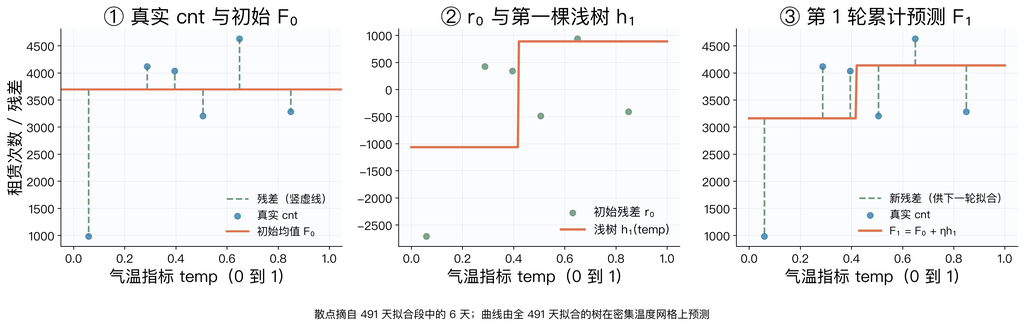

|  | 原始索引 | 日期 | 温度 | 真实cnt | 初始预测 | 初始残差 | 第1轮树 | 第1轮预测 | 第1轮残差 | 第2轮树 | 第2轮预测 | 第2轮残差 |
| --- | --- | --- | --- | --- | --- | --- | --- | --- | --- | --- | --- | --- |
| 0 | 21 | 2011-01-22 | 0.1 | 981 | 3693.7 | -2712.7 | -1065.3 | 3161.0 | -2180.0 | -1037.2 | 2642.4 | -1661.4 |
| 1 | 434 | 2012-03-10 | 0.3 | 4118 | 3693.7 | 424.3 | -1065.3 | 3161.0 | 957.0 | -1037.2 | 2642.4 | 1475.6 |
| 2 | 310 | 2011-11-07 | 0.4 | 4035 | 3693.7 | 341.3 | -1065.3 | 3161.0 | 874.0 | 317.2 | 3319.6 | 715.4 |
| 3 | 108 | 2011-04-19 | 0.5 | 3204 | 3693.7 | -489.7 | 886.4 | 4136.9 | -932.9 | 317.2 | 4295.5 | -1091.5 |
| 4 | 268 | 2011-09-26 | 0.6 | 4630 | 3693.7 | 936.3 | 886.4 | 4136.9 | 493.1 | 317.2 | 4295.5 | 334.5 |
| 5 | 203 | 2011-07-23 | 0.8 | 3285 | 3693.7 | -408.7 | 886.4 | 4136.9 | -851.9 | 317.2 | 4295.5 | -1010.5 |

```
初始值：全491天 cnt 均值 3693.670061；全量核对最大差：{'轮1全491条最大差': 0.0, '轮2全491条最大差': 0.0}。
```

```python
pred2_grid = pred1_grid + .5*h2_grid
plots.residual_stages(preview_x, preview_y, residual0[preview_idx], boost_grid, h1_grid, initial, pred1_grid, ASSETS / "l7-bike-residual.svg", pred1_samples=pred1[preview_idx])
display(Image(filename=str(ASSETS / "l7-bike-residual.png")))
display(pd.DataFrame({"原始索引":fit_frame.index[preview_idx],"日期":fit_frame.iloc[preview_idx].dteday.dt.strftime("%Y-%m-%d").to_numpy(),"温度":preview_x,"真实cnt":preview_y,"初始预测":np.repeat(initial,len(preview_y)),"初始残差":residual0[preview_idx],"第1轮树":h1_model.predict(preview_x[:,None]),"第1轮预测":pred1[preview_idx],"第1轮残差":residual1[preview_idx],"第2轮树":h2_model.predict(preview_x[:,None]),"第2轮预测":pred2[preview_idx],"第2轮残差":residual2[preview_idx]}).round(1))
print(f"初始值：全491天 cnt 均值 {initial:.6f}；全量核对最大差：{boost_check}。")
```

## 17. 梯度提升回归（GBDT）：预测如何逐轮改进

从上一页的气温单特征机制演示，转到全部8个输入：气温、湿度、风速、工作日、节假日、季节、月份和年份。模型仍用前491天训练，单树深度由机制演示的1改为3，以允许特征交互。固定抽取同一组60天展示，五图坐标一致。点越接近对角线，预测越接近真实值；图中MSE在全部491天计算。训练拟合改善不保证验证表现也改善。

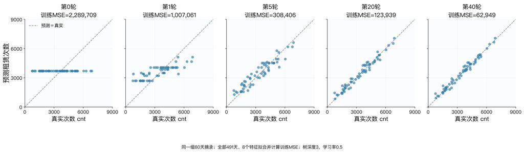

```python
# 使用全部8个特征拟合，60条随机摘录只用于画点。
boost_forty = GradientBoostingRegressor(n_estimators=40, learning_rate=.5,
    max_depth=3, loss="squared_error", random_state=42).fit(fit_frame[forest_features], y_fit)
show_idx = np.sort(np.random.default_rng(42).choice(len(y_fit), 60, replace=False))
round_predictions = {0: np.full(len(y_fit), initial)}
for m, fit_pred in enumerate(boost_forty.staged_predict(fit_frame[forest_features]), start=1):
    if m in (1, 5, 20, 40):
        round_predictions[m] = fit_pred
round_mse = {m: mean_squared_error(y_fit, pred) for m, pred in round_predictions.items()}
plots.boost_sum(y_fit, show_idx, round_predictions, round_mse, ASSETS / "l7-bike-boost-sum.svg")
display(Image(filename=str(ASSETS / "l7-bike-boost-sum.png")))
```

### 补充观察：回归预测分区

回归没有分类决策边界。下面展示八特征模型的二维切片：只改变气温和湿度，其余六项固定为第151条训练记录的值。颜色代表预测租赁次数，五个面板共用色标。这不是整个八维输入空间，也不是对其他特征取平均；部分组合可能偏离真实数据分布。

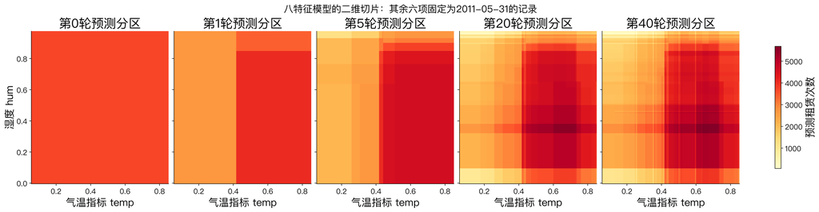

```python
# 只画模型的预测分区，不在二维切片上混入不同条件的真实标签。
plots.boost_prediction_slices(boost_forty, fit_frame, forest_features, initial, ASSETS / "l7-bike-boost-slices.svg")
display(Image(filename=str(ASSETS / "l7-bike-boost-slices.png")))
```

## 18. 梯度提升：学习率与轮数如何选择？

沿用上一节的8个输入和单树深度3，使用前491天训练、随后120天开发验证，比较学习率0.01、0.1、1.5、2，最多200轮。同色虚线为训练、实线为验证。大于1的设置用于观察过量修正，不作为常规选参建议。

**sklearn建议**：默认学习率为0.1。用户指南引用的经验建议是较小学习率（例如≤0.1）配足够多的树，再根据验证表现早停。每轮只采用部分修正可起到正则化作用，但较小步长往往需要更多轮；不能仅在固定200轮内比较后就断言越大越好。[默认参数](https://scikit-learn.org/stable/modules/generated/sklearn.ensemble.GradientBoostingRegressor.html) · [学习率与轮数](https://scikit-learn.org/stable/modules/ensemble.html#shrinkage-via-learning-rate)。

**本次观察**：0.01下降较慢；0.1在第89轮取得该候选的最低验证MSE，约704,991；1.5训练误差接近0但验证仍差，2持续震荡。第89轮是当前开发验证段上的选择，不是独立测试结论。

**轮数选择**：对每个候选学习率，用`staged_predict`计算各轮验证MSE，再比较最低值与对应轮数。本例候选范围内选择学习率0.1、第89轮；若最低点仍在上限且曲线明显下降，应增加上限后再比较。

**早停实现**：sklearn的`n_iter_no_change`、`tol`可控制自动早停，`validation_fraction`划出内部验证集。自动停止的轮数不一定等于完整验证曲线最低点所在轮数。本课按时间评价，继续使用固定后续120天作验证，不启用内部随机划分。[官方早停示例](https://scikit-learn.org/stable/auto_examples/ensemble/plot_gradient_boosting_early_stopping.html)。

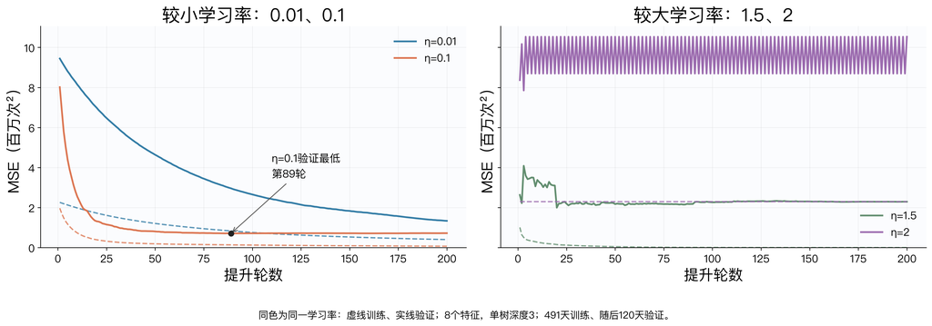

|  | 学习率 | 最低验证MSE | 对应轮数 | 第200轮训练MSE | 第200轮验证MSE |
| --- | --- | --- | --- | --- | --- |
| 0 | 0.0 | 1334110.2 | 200 | 398360.1 | 1334110.2 |
| 1 | 0.1 | 704990.9 | 89 | 64472.9 | 718973.4 |
| 2 | 1.5 | 1992776.5 | 20 | 99.5 | 2289807.3 |
| 3 | 2.0 | 7847148.1 | 3 | 2289709.4 | 10530745.4 |

```python
rates = [.01, .1, 1.5, 2.0]
boost_train_curves, boost_valid_curves = [], []
for rate in rates:
    # 与上一节统一8个输入和深度3，仅改变学习率，最多训练200轮。
    model = GradientBoostingRegressor(n_estimators=200, learning_rate=rate, max_depth=3, random_state=42)
    model.fit(fit_frame[forest_features], y_fit)
    boost_train_curves.append([mean_squared_error(y_fit,p) for p in model.staged_predict(fit_frame[forest_features])])
    boost_valid_curves.append([mean_squared_error(dev_valid["cnt"],p) for p in model.staged_predict(dev_valid[forest_features])])
plots.boost_rates(np.arange(1,201), boost_train_curves, boost_valid_curves, rates, ASSETS / "l7-bike-boost-rate.svg")
display(Image(filename=str(ASSETS / "l7-bike-boost-rate.png")))
rate_summary = pd.DataFrame([{"学习率":rate, "最低验证MSE":min(va), "对应轮数":int(np.argmin(va))+1,
    "第200轮训练MSE":tr[-1], "第200轮验证MSE":va[-1]} for rate,tr,va in zip(rates,boost_train_curves,boost_valid_curves)])
display(rate_summary.round(1))
_ = (ASSETS / "l7-boost-rate-results.json").write_text(json.dumps({"max_depth":3,"fit_rows":491,"validation_rows":120,
    "features":forest_features,"rates":rates,"summary":rate_summary.to_dict("records"),
    "train_mse":boost_train_curves,"validation_mse":boost_valid_curves},ensure_ascii=False,indent=2))
```